# Mapping global conservation priorities and habitat vulnerabilities for cave-dwelling bats in a changing world - ScienceDirect

## [Science of The Total Environment](https://www.sciencedirect.com/journal/science-of-the-total-environment)

[Volume 843](https://www.sciencedirect.com/journal/science-of-the-total-environment/vol/843/suppl/C), 15 October 2022, 156909

# Mapping global conservation priorities and habitat vulnerabilities for cave-dwelling bats in a changing world

https://doi.org/10.1016/j.scitotenv.2022.156909[Get rights and content](https://s100.copyright.com/AppDispatchServlet?publisherName=ELS&contentID=S0048969722040062&orderBeanReset=true)

Under a Creative Commons [license](http://creativecommons.org/licenses/by-nc/4.0/)

open access

## Highlights

**•**

Bats provide vital ecosystem services and are keystone species to cave ecosystems.

**•**

Almost half of the global bats are known to use caves.

**•**

679 species and 1930 caves from 46 countries were analysed in this study.

**•**

Up to 28 % of caves are a high conservation priority and mostly in the tropics.

**•**

Optimising prioritisation parameters is important for effective cave management.

## Abstract

Research and media attention is disproportionately focused on taxa and ecosystems perceived as charismatic, while other equally diverse systems such as caves and subterranean ecosystems are often neglected in biodiversity assessments and prioritisations. Highlighting the urgent need for protection, an especially large fraction of cave [endemic species](https://www.sciencedirect.com/topics/earth-and-planetary-sciences/endemic-species) may be undescribed. Yet these more challenging systems are also vulnerable, with [karsts](https://www.sciencedirect.com/topics/earth-and-planetary-sciences/karst) for example losing a considerable proportion of their area each year. Bats are keystone to cave ecosystems making them potential surrogates to understand cave diversity patterns and identify conservation priorities. On a global scale, almost half (48 %) of known bat species use caves for parts of their life histories, with 32 % endemic to a single country, and 15 % currently threatened. We combined global analysis of cave bats from the IUCN spatial data with site-specific analysis of 1930 bat caves from 46 countries to develop global priorities for the conservation of the most vulnerable subterranean ecosystems. Globally, 28 % of caves showed high bat diversity and were highly threatened. The highest regional concentration of conservation priority caves was in the Palearctic and tropical regions (except the Afrotropical, which requires more intensive cave data sampling). Our results further highlight the importance of prioritising bat caves by incorporating locally collected data and optimising parameter selection (i.e., appropriate landscape features and threats). Finally, to protect and conserve these ecosystems it is crucial that we use frameworks such as this to identify priorities in species and habitat-level and map vulnerable underground habitats with the highest biodiversity and distinctiveness.

## Graphical abstract

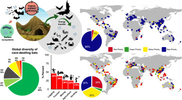

## Keywords

Bioindicators

Evolutionary distinctiveness

Extinction risks

Island endemism

Subterranean habitats

## 1. Introduction

We are currently facing the sixth [mass extinction](https://www.sciencedirect.com/topics/earth-and-planetary-sciences/mass-extinction), with a higher rate of extinction than at any time since former mass extinctions millions of years ago (Ceballos et al., 2015; Cowie et al., 2017; Vos et al., 2015). As much as conservation scientists try to address the most pressing challenges in global biodiversity conservation, many taxa and their associated habitats are consistently overlooked (Clark and May, 2002). Appropriate evidence-based strategies are essential to optimise the implementation and effectiveness of conservation efforts (Ceballos et al., 2015; Pimm et al., 2014). Various methods and frameworks have been developed to prioritise taxa and their habitats for conservation such as habitat prioritisation and zoning (Conenna et al., 2017; Hernández-Quiroz et al., 2018; Wintle et al., 2019). Yet many countries may have limited access to such data or resources to effectively implement conservation efforts for understudied, yet potentially vulnerable habitats (Chandra and Idrisova, 2011). Many species lack the data needed for effective priorities to be developed (Dolman et al., 2012; Halpern et al., 2006). Whilst approaches such as the IUCN Red List of ecosystems, and the new ecosystem typology goes some way in enabling proactive targeting of ecosystems, including those with high numbers of [endemic species](https://www.sciencedirect.com/topics/earth-and-planetary-sciences/endemic-species).

Human activities have already transformed at least 70 % of [terrestrial ecosystems](https://www.sciencedirect.com/topics/earth-and-planetary-sciences/terrestrial-ecosystem) to support human populations (Ellis et al., 2013). Using modern technologies, environmental processes and threats on above-ground surface ecosystems (e.g., forest ecosystems) can easily be mapped with [remote sensing](https://www.sciencedirect.com/topics/earth-and-planetary-sciences/remote-sensing) (Rose et al., 2015). Yet most subterranean ecosystems such as caves are challenging to map and have frequently been overlooked and neglected in prioritisation (Mammola et al., 2019; McClure et al., 2020; Sánchez-Fernández et al., 2021). Up to 90 % of species in a single cave may be undescribed in some countries (Manenti et al., 2018; Whitten, 2009), meaning many thousands of species remain undescribed and potentially at risk (Ficetola et al., 2019). However, most conservation projects and funds are focused on taxa generally considered to be charismatic (Ford et al., 2017), but neglect fragile ecosystems with high endemism such as cave ecosystems (Mammola et al., 2021, Mammola et al., 2019; Manenti et al., 2018). Subterranean ecosystems are threatened by both immediate threats to the caves themselves, and modifications of the surrounding environment (Phelps et al., 2016; Tanalgo et al., 2018). Many caves and karst habitats are under-protected, for example, only around 13 % of the approximately 800,000 km<sup>2</sup> of tropical Southeast Asian karsts are within protected areas (Day and Urich, 2000). Unprotected karst is especially susceptible to human activities and destruction, for example in Southeast Asia the average loss is around 5.7 % of the area annually due to mineral mining (Clements et al., 2006; Hughes, 2017; Liew et al., 2016).

The low reproductive rate in bats prevents rapid population recovery following population decreases (Barclay et al., 2004; Frick et al., 2019; Sagot and Chaverri, 2015), yet bats receive little public support and funding compared to other large mammals (Fleming and Bateman, 2016). The loss of cave bat habitats is coupled with unregulated hunting and tourism, and loss of foraging habitat; therefore, understanding the impacts of these factors on the population status of bats and biotically important caves are urgently needed (Furey and Racey, 2016; Sedlock et al., 2014; Tanalgo et al., 2018; Torres-Flores and Santos-Mreno, 2017). In addition to bats, cave ecosystems host a variety of highly adapted, endemic, and sensitive organisms, many of which are cave obligate and dependent on bat guano for nutrients (Deharveng and Bedos, 2018; Ferreira, 2019; Furey and Racey, 2016; Simon, 2019). It is estimated that at least 50 % of global bat species rely at least partially upon caves (Furey and Racey, 2016) but the degree of threat to bat cave communities and prioritisation has never been analysed on a global scale (Tanalgo et al., 2018). However, there are few large-scale and standardised approaches to identify conservation priorities for caves, hindering comparative global prioritisation to protect cave systems and their dependent diversity (Cajaiba et al., 2021; Tanalgo et al., 2018).

Because measuring cave diversity is challenging, biodiversity surrogates such as umbrella species can be used to guide targeting conservation for large cave communities (Caro, 2010; Lewandowski et al., 2010; Lindenmayer and Westgate, 2020; Margules et al., 2002). Within cave ecosystems, bats are [keystone species](https://www.sciencedirect.com/topics/earth-and-planetary-sciences/keystone-species) making them ideal ecological indicators and conservation surrogates to inform ecosystem health and priorities to safeguard (Cunha et al., 2020; Ferreira, 2019; Schneider et al., 2011). This study is the first extensive study to explore the global diversity patterns and extinction risk of cave-dwelling bats and using this information to create an index to guide effective conservation priority setting of their habitats. Here we developed a framework to understand the species and site-specific priorities and integrate different facets of biotic importance and risks across different scales to map habitat-level priorities for cave-dwelling bats. First, we examined the priorities at the species-level by understanding the (i) patterns of diversity, distribution, and extinction risks of cave-dwelling bats, and (ii) patterns and severity of threats to species. Second, we assessed habitat-level priorities by mapping the broad-scale and fine-scale priorities of bat caves based on cave biotic potential and threat vulnerability. We aim to assess gaps in species information and to identify both priorities for research and sites most in need of conservation intervention.

## 2. Materials and methods

In this paper, we developed a two-step prioritisation for bat caves: species-level and habitat-level (Fig. 1). At the species-level, we used the IUCN Red list database and species traits to assess species diversity, characteristics, distribution, and extinction risk. While for habitat-level prioritisation, we used the global version of the Bat Cave Vulnerability Index (BCVI<sub>global</sub>) to assay the conservation priorities of bat caves in different scales.

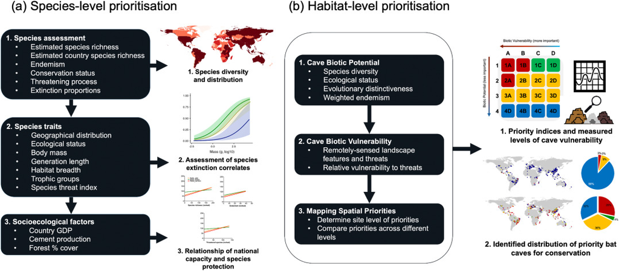

1. [Download : Download high-res image (579KB)](https://ars.els-cdn.com/content/image/1-s2.0-S0048969722040062-gr1_lrg.jpg)
2. [Download : Download full-size image](https://ars.els-cdn.com/content/image/1-s2.0-S0048969722040062-gr1.jpg)

Fig. 1. Schematic diagram showing the framework of (a) species-level and (b) habitat-level prioritisation for cave-dwelling bats. At the species-level analysis, we used the information from the IUCN Red list database and combined this to other database of species traits to assess species diversity, distribution, and extinction risks. We also assessed country's capacity to protect species by combining information from estimated species richness and socioecological factors. While for habitat-level prioritisation, we assessed and compared (in broad- and fine-scales) the conservation priority of bat caves using the Global Bat Cave Vulnerability Index (BCVIglobal).

### 2.1. Species-level prioritisation

We sampled global cave-dwelling bats from two open databases, the IUCN Red list (v. 2020.1) and the DarkCideS (v 1.0) (https://darkcides.org/database/), which contains a consolidated global dataset for cave-dwelling bats (Tanalgo et al., 2022), including all known species that occur, use, roost, or hibernate in caves and subterranean habitats for any part of their life histories (Data S1, Data S2, Data S3). All species names were curated and updated using the Bats of the World: A taxonomic and geographic database (Simmons and Cirranello, 2020). We included species-specific information including species taxonomy, endemism at geopolitical and biogeographical scales, species range and distributions, conservation status, population trends, ecological traits, and threatening processes. The habitat breadth was determined according to the number of habitats a species occurs in (Etard et al., 2020), and used the weighted habitat breadth (%) values in the final analyses.

Species were then classified based on island endemism and country (geopolitical) endemism. Whilst country endemism is not strictly an ecological indicator, it is nonetheless useful as if a species is only present in a single country, then the survival of that species is also subject to the policies of a single country, which increases vulnerability if protection measures are not in place (Ceballos and Ehrlich, 2002).

[Species conservation](https://www.sciencedirect.com/topics/earth-and-planetary-sciences/species-conservation) status was assessed according to the IUCN Red list criteria, whilst Data Deficient (DD) species were counted as threatened in estimating country-level species richness, as they may face higher or similar threats, hence a lack of data for formal classification (Bland et al., 2015; Tanalgo et al., 2018, Welch and Beaulieu, 2018). We compared patterns of species diversity across biogeographical realms (Olson and Dinerstein, 1998; Olson et al., 2001). Chi-square test (χ<sup>2</sup>) of association was then used to assess the relationship in species geopolitical endemism, island endemism, conservation status, and population status. Additionally, using Kendall's *τ* B, we explored the relationships between (i) country estimated species richness, (ii) % endemic species, and (iii) % threatened to country land area (km<sup>2</sup>) (Supplementary methods).

#### 2.1.1. IUCN-based species extinction risk

We estimated the extinction risks for different groups and species ecological status by updating their IUCN status to reflect their current status. The proportion of threatened species was estimated across biogeographical realms, species endemism (e.g., geopolitical and island), population trends, [trophic levels](https://www.sciencedirect.com/topics/earth-and-planetary-sciences/trophic-level), and families (Hoffmann et al., 2010; Richman et al., 2015). The proportion of vulnerable species (*p̂* <sub>extinction</sub>) was calculated based on the proportion of threatened species as *p̂* <sub>extinction</sub> = (*N*<sup>*o*</sup> <sub>threatened</sub>) / (*N*<sup>*o*</sup> <sub>species</sub> − *DD* <sub>species</sub>), where *N*<sup>*o*</sup> <sub>threatened</sub> is the number of threatened species assessed as Vulnerable (VU), Endangered (EN), and Critically Endangered (CE), *N*<sup>*o*</sup> <sub>species</sub> is total richness, and *DD* is the number of Data Deficient species, assuming that *DD* species will have a similar extinction risk as of other threatened categories (Richman et al., 2015; Tanalgo et al., 2018). We then calculated the lower estimate (*p̂* <sub>extinction_lower</sub> = *N*<sup>*o*</sup> <sub>threatened</sub> / *N*<sup>*o*</sup> <sub>species</sub>) with an assumption that *DD* species are categorised as non-threatened and the upper estimates (*p̂* <sub>extinction_upper</sub> = *N*<sup>*o*</sup> <sub>threatened</sub> + *DD* / *N*<sup>*o*</sup> <sub>species</sub>) with the assumption that *DD* is threatened.

A binomial generalised linear model (GLM) was used to determine the predictors of species extinction risk (threatened vs. non-threatened) for global species and within each suborder, Yinpterochiroptera and Yangochiroptera. We tested ten explanatory variables previously identified as important extinction correlates for bats (e.g., (Jones et al., 2003; Welch and Beaulieu, 2018)), which included (i) geographical variables (geographical range, island endemism, and geopolitical endemism), (ii) biological variables ((adult body mass (kg, log<sub>10</sub>) (Faurby et al., 2018), generation length (Pacifici et al., 2013), forest dependency (yes or no based on the IUCN database), weighted habitat breadth (%), and trophic group)), and the number of threats per species (Supplementary methods).

#### 2.1.2. Comparing species threats

Threats per species were based on IUCN Red List assessments. We modified the threat nomenclature by Salafsky et al. (2008) to better reflect threats to bat caves. We reclassified threats as Direct, Indirect, and Natural (Supplementary methods). The Species Threat Index (*STI*) is calculated from the quotient of the sum of species absolute threat (*T* <sub>dir, ind, nat</sub>) and the number of threats (*N*<sup>*o*</sup> *T*) (*STI* <sub>species</sub> = Σ *T* / *N*<sup>*o*</sup> *T*). We compared *STI* across biogeographical realms, endemicity, conservation status, and population trend using a non-parametric Kruskal-Wallis test.

A separate generalised linear model (GLM) with a binomial distribution (logit link function) in JAMOVI version 2, using GAMLj module (Gallucci, 2019) was used to assess species risk to a certain threatening process based on their traits e.g., Atwood et al. (2020) and Fritz et al. (2009). We used adult body mass (g, log<sub>10</sub>), geographical range (log<sub>10</sub>) and trophic levels as the predictor variable and threat status (threatened or not threatened) as the response variables (Atwood et al., 2020). We only incorporated threatening processes that threaten >10 % of global cave-dwelling bats (Table S7). Lastly, we ranked and correlate country species richness, the proportion of threatened and endemic species to sociodemographic and environmental indicators as rudimentary indicators of a country's resources representing its capacity to monitor and protect its species and environment (e.g., Convention of Biological Diversity) (Amori et al., 2011; McGeoch et al., 2010).

### 2.2. Habitat-level prioritisation

We modified the first version of BCVI (Tanalgo et al., 2018) to enable comparative global-scale prioritisation in the new BCVI<sub>global</sub>. This prioritisation index integrates cave biotic potential and vulnerability. The first component of the index is the cave Biotic Potential (BP), which analyses bat diversity and endemism. The second component is the cave Biotic Vulnerability (BV) which measures the cave landscape features and vulnerability to threats. Using the index, we mapped and constructed broad-scale (from IUCN) and fine-scale (from site-specific data) cave priorities.

#### 2.2.1. Cave biotic potential (BP)

Biotic Potential (BP) represents bat biodiversity (Tanalgo et al., 2018). For global analysis population estimates (e.g., bat counts in caves) were excluded to remove the bias from the missing and unstandardised assessments but can be used at local scales (see Tanalgo et al., 2022). In addition to species attribute scoring (conservation status, population trends, country endemism, and island endemism) (Table S1), we incorporated evolutionary units using calculated evolutionary distinctiveness (ED, from the EDGE score (Isaac et al., 2007)) and corrected weighted endemism (CWE) to determine the cave biotic potential (BP). Corrected weighted endemism (CWE) was calculated by dividing weighted endemism (WE) by richness (e.g., absolute counts of species) (Crisp et al., 2001; Laffan and Crisp, 2003). We then calculated BP using the equation: BP<sub>cave x</sub> = Σ *S*<sub>cave x</sub> / max Σ *S*<sub>cave y</sub>, where cave BP is the calculated quotient of the sum of cave species attributes scores (Σ *S*<sub>cave x</sub>) and the highest maximum (Σ *S*<sub>cave y</sub>) sum of species attribute scores from all sampled caves (<sub>cave y</sub>) within the single site or the entire biome: *S*<sub>cave x</sub> = Σ Species n<sup>th</sup> (ED + CWE (× 100) + *Cons* + *Pops* + *E* + *Isl*) + Species n<sup>th</sup> (ED + CWE (× 100) + *Cons* + *Pops* + *E* + *Isla*) + …Species n<sup>th</sup> (ED + CWE (× 100) + *Cons* + *Pops* + *E* + *Isl*), where *S* <sub>cave x</sub> is the sum score of n<sup>th</sup> bat cave species evolutionary distinctiveness (ED), corrected weighted endemism (× 100) (CWE), conservation status (Cons), population trends (Pops), country endemism (E), and island endemism (Isl) (Table S1).

The BP<sub>cave</sub> index score ranges from 0.00 to 1.00, where values near 1.00 indicate higher cave biotic potential and are scaled to four levels of priority (Table S2).

#### 2.2.2. Mapping landscape features and cave vulnerability (BV)

Cave BP is synergised with cave Biotic Vulnerability (BV) to derive the final cave alphanumeric priority. We mapped and measured the extent of geophysical features and threats in a single cave following Hughes (2019) using ArcGIS version 10.3 (see Tanalgo et al., 2022 for detailed GIS variable methods). We assessed the correlation between landscape variables, cave species biotic scores and the extent was compared across biogeographical realms using Kendall's *τ* B correlation. We selected representative features for the BV calculations: (i) distance to urban area, (ii) distance to roads, (iii) tree density, (iv) canopy cover, (v) mining density, and (vi) distance to water bodies (for arid biomes). We calculated cave Biotic Vulnerability (BV<sub>cave</sub>) as the quotient of summed scores of all the geophysical features or landscape (*NT*) and the total number of geophysical features assessed (*N*<sup>o</sup>, *N*<sup>*o*</sup> *=* 5): BV = Σ *NT*/*N*<sup>*o*</sup>, where *NT* (*NT* = *T x* / *T*<sub>max</sub> y) is the score of geophysical or landscape features (*T*) in a specific cave (*T* x) divided by the maximum value in all sampled caves (*T*<sub>max</sub> y). The *N* score ranges from 0.00 to 1.00 and is scaled by a four-level range score (Table S3).

#### 2.2.3. Mapping cave conservation priorities

We performed BCVI<sub>global</sub> prioritisation at two spatial scales. First, the broad-scale priorities represent biome-dependent analyses. Secondly, we measured the site-level diversity and vulnerability to encompass the fine-scale prioritisation.

Cave priorities were set at a national scale, with the assumption that priorities should be comparable to guide decision-making at any scale. The alphanumeric index derived from BCVI<sub>global</sub> was divided into four priority scales (Table 1). Mean biotic vulnerability (i.e., values of 1-high threat to 4-low threat) was compared to cave biotic potential status. Priorities from both scales were assessed across biogeographical realms and biomes using a chi-square test (χ<sup>2</sup>). We used Pielou's index in PAST (Hammer et al., 2001) to assess evenness in BCVI<sub>global</sub> and priorities between scales.

Table 1. Four-level priority scales for bat caves using the Global Bat Cave Vulnerability Index (BCVI<sub>global</sub>).

| BCVI<sub>global</sub> | Priority-level | Condition | Potential action |
| --- | --- | --- | --- |
| 1A, 1B, 2A | Red Priority caves | High diversity and high threat exposure. | Cave needs immediate action. |
| 1D, 1C | Green Priority caves | High diversity, but threat exposure is absent. | Cave needs monitoring. |
| 2B, 2C, 2D, 3A, 3B, 3C, 3D | Yellow Priority caves | Under high threat, and moderate diversity. May have already lost species. | Cave needs intervention or may least concern for conservation. |
| 4A, 4B, 4C, 4D | Blue Priority caves | High to low threat, with very low diversity. May have already lost species. | Cave that is least concern. |

## 3. Results

### 3.1. Species-level priorities

#### 3.1.1. Global diversity and distribution of cave-dwelling bats

Globally, 32 % of cave-dwelling bat species were endemic to a single country and 23 % to small islands. Most of the geopolitically endemic species are classified as threatened (63.58 %, *N =* 110 spp.) compared to less threatened (21.74 %, *N =* 63 spp.) (χ<sup>2 *=*</sup> 120.50, *df =* 5, *P <* 0.0001). Most data deficient species (57 %, *N =* 47 spp.) are country endemic. Moreover, the distribution of island endemic species significantly differed across conservation statuses (χ<sup>2</sup> = 192, *df =* 2, *P* < 0.001). The 77 % (*N =* 520 spp.) of the species are found on mainland and near-shore islands and 23 % (*N =* 159 spp.) are restricted to islands (Fig. 2). Unsurprisingly, 75 % of island species are country endemic versus 81 % of the non-endemic occur in mainland areas (χ<sup>2 *=*</sup> 171, *df =* 1, *P <* 0.001). Moreover, the proportion of species in threatened categories within island endemism is higher for island restricted species (40 %; *N* = 43 spp.) compared to mainland species (21 %; *N =* 173 spp.) (χ<sup>2 *=*</sup> 35.4, *df =* 2, *P <* 0.001).

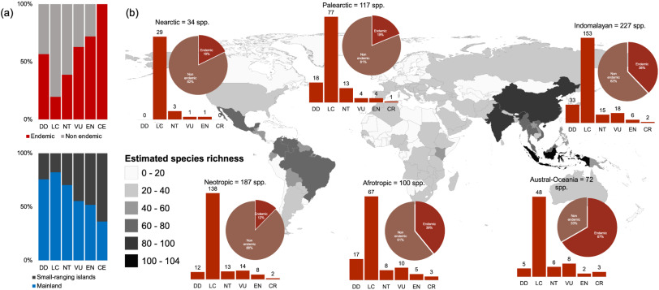

1. [Download : Download high-res image (290KB)](https://ars.els-cdn.com/content/image/1-s2.0-S0048969722040062-gr2_lrg.jpg)
2. [Download : Download full-size image](https://ars.els-cdn.com/content/image/1-s2.0-S0048969722040062-gr2.jpg)

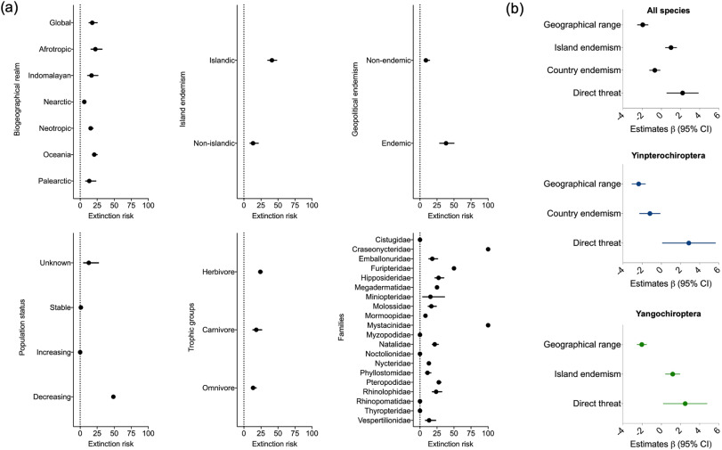

1. [Download : Download high-res image (265KB)](https://ars.els-cdn.com/content/image/1-s2.0-S0048969722040062-gr3_lrg.jpg)
2. [Download : Download full-size image](https://ars.els-cdn.com/content/image/1-s2.0-S0048969722040062-gr3.jpg)

Fig. 3. IUCN-based extinction risk. (a) Estimated extinction risks (*p̂* <sub>*extinction*</sub>) of global cave-dwelling bat species compared by biogeographical realm, island endemism, geopolitical endemism, population trends, trophic groups, sub-orders and families. Estimated extinction proportion (*p̂* <sub>*extinction*</sub>) for global species (blue dashed line) and all cave-dwelling bats (red dashed line) is provided. All computed values are supplemented in Table S2. (b) Estimate coefficients of significant determinants extinction risks of all global species, and among suborders Yinpterochiroptera and Yangochiroptera. Summary of binomial generalised linear mixed (GLMs) explaining species extinction risks is provided in Table S3.

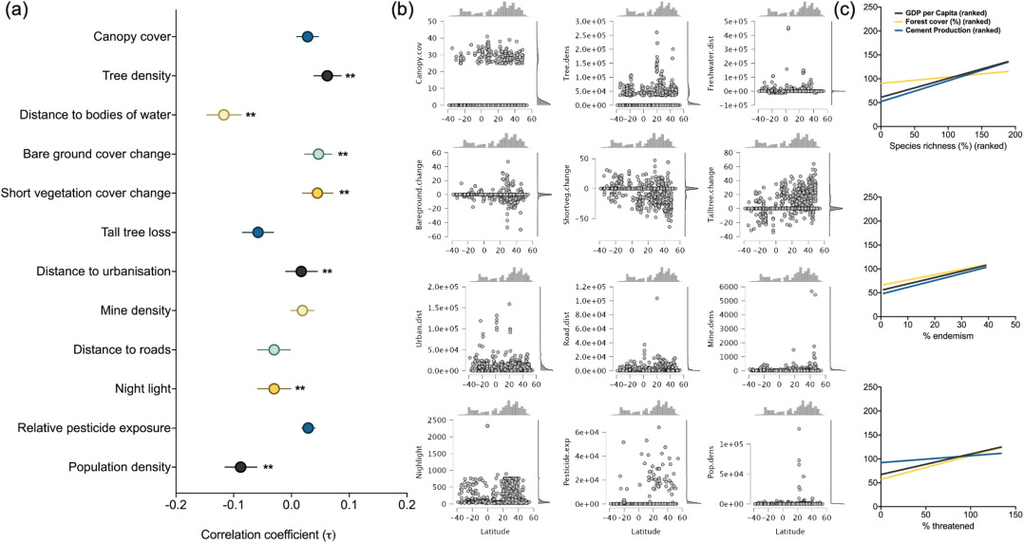

1. [Download : Download high-res image (462KB)](https://ars.els-cdn.com/content/image/1-s2.0-S0048969722040062-gr4_lrg.jpg)
2. [Download : Download full-size image](https://ars.els-cdn.com/content/image/1-s2.0-S0048969722040062-gr4.jpg)

Fig. 4. Relationship, extent, and distribution of threats among assessed global cave sites. (a) [Correlation coefficients](https://www.sciencedirect.com/topics/earth-and-planetary-sciences/correlation-coefficient) (τ and 95 % CI intervals) between landscape features and threats and species cave biotic scores, (b) biogeographic comparison of mean intensity of vulnerabilities to landscape features and threats. When compared regionally, the mean intensity of landscape features and threat variables differed significantly except for relative exposure to pesticide. Bat caves in the Afrotropical, Austral-Oceania and [Nearctic regions](https://www.sciencedirect.com/topics/earth-and-planetary-sciences/nearctic-region) showed the highest vulnerability to distance to urban areas. While Nearctic caves showed the nearest distance to roads and the highest mapped mine density. The mean proportion of bare ground cover change is low in arid regions of the Afrotropical and Austral-Oceania. Whereas population density and relative pesticide exposure are exceedingly high in Indomalayan caves, highlighting potentially high deforestation and loss of natural habitats. (c) Global concordance of between country socioecological indicators (country GDP, Forest cover, cement export production) and species attributes (up to down: country species richness, endemism, and proportion of threatened species). (Values with ** showed significance at *P <* 0.05).

#### 3.1.2. Patterns of threat and extinction risks

Using the IUCN data, the estimated extinction risks of cave-dwelling bat species (*p̂* <sub>extinction</sub> = 15 %, 13–25 %) are lower than that of all bat species (*p̂* <sub>extinction</sub> = 20 %, 16–35 %), of which 37 % are in a threatened category and 12 % are data deficient (Fig. 3a, Table S5). Overall extinction risk of global cave-dwelling bats is relatively lower but higher when compared across sub-orders, families, and trophic groups (Fig. 3a). Moreover, country endemic species (*p̂* <sub>extinction</sub> = 36 %, 29–50 %) and species occurring on islands (islandic: *p̂* <sub>extinction</sub> = 40 %, 35–48 %) are facing exceedingly high extinction risk (Fig. 3a, Table S5). Additionally, a strong link between narrow geographic range and species extinction risk can be attributed in all cave-dwelling species (*β =* −1.94, *P <* 0.001) and for both suborder models (Yinchiroptera: *β =* −2.34, *P <* 0.001; Yangochiroptera: *β =* −2.02, *P <* 0.001). Country endemic (*β =* −0.67, *P =* 0.013) and island endemic (*β =* 1.00, *P <* 0.001) species are also linked to higher extinction risk globally (Fig. 3a). But varies within suborders, Yangochiroptera that are island endemic (*β =* 1.17, *P <* 0.001) are at higher risk, while only geopolitically endemic Yinchiroptera (*β =* −1.19, *P =* 0.028) are at higher risk compared to more widespread species (Fig. 3b, Table S6). Furthermore, none of the biotic variables (trophic level, generation length, and adult body mass) included in the model could predict extinction risk globally and within suborders. Among threat variables, only direct threats showed significant association globally (*β =* 2.221, *P =* 0.008) and between suborders (Yinchiroptera: *β =* 2.84, *P =* 0.043; Yangochiroptera: *β =* 2.50, *P =* 0.031) (Fig. 3b).

Nearly three-quarters (69 %, *N =* 466 spp.) of the cave-dwelling bat species are exposed to various threats according to the IUCN. The proportion of direct (Kruskal-Wallis test: χ<sup>2</sup> *=* 13.02 *df =* 5, *P =* 0.02) and indirect (Kruskal-Wallis test: χ<sup>2</sup> *=* 30.10, *df =* 5, *P <* 0.01) threats differed regionally. However, there is a large disparity in the species threatened by natural threats with only 10 % (*N =* 70 spp.) (*STI* <sub>*nat*</sub> = 1.40) of the species assessed facing geo-climatically induced threats (Fig. S1, Table S7). Species risks to dominant threats such as agricultural conversion (*β = −*0.214, *P =* 0.017) and deforestation (*β = −*0.154, *P =* 0.05) were significantly linked to small geographic range. Conversely, species with large geographic ranges were more at risk from pollution (*β =* 0.498, *P =* 0.003). Species adult body mass is a strong predictor of species vulnerability for hunting and bushmeat for large species (*β =* 0.845, *P <* 0.001). Within trophic levels, omnivores have a significantly higher risk from mining and quarrying compared to frugi-nectarivores (*β =* −1.029, *P =* 0.023) and carnivores (*β = −*0.636, *P =* 0.026). Frugi-nectarivores are more vulnerable to hunting and harvesting (*β =* 2.256, *P =* 0.001), and [insectivores](https://www.sciencedirect.com/topics/earth-and-planetary-sciences/insectivore) to pollution (*β =* 1.483, *P =* 0.044) compared to other trophic levels (Fig. S2 and Table S8).

### 3.2. Habitat-level priorities

#### 3.2.1. Mapping vulnerable and priority sites for cave-dwelling bats

The degree of evolutionary distinctiveness (ED) constructed on bat cave data significantly differed regionally (Kruskal-Wallis, χ<sup>2</sup> *=* 1615.65, *df =* 5, *P <* 0.001). The highest ED was in the [Neotropical region](https://www.sciencedirect.com/topics/earth-and-planetary-sciences/neotropical-region) (ED<sub>mean</sub> = 11.92) with the lowest in the Palearctic (ED<sub>mean</sub> = 5.54). Cave weighted endemism is highest in the Austral-Oceania (CWE<sub>mean</sub> = 6.32) consistent with the proportion of species endemism observed in the region (Kruskal-Wallis, χ<sup>2</sup> *=* 1584.84, *df =* 5, *P <* 0.01) (Fig. 5). Prioritisation at broad and fine scales showed that most cave sites are highly vulnerable to threats (Fig. 6a-d). In fine-scale analysis, we found a significant relationship in biotic potential and biotic vulnerability score (Kruskal-Wallis test: χ<sup>2</sup> *=* 14, *df =* 3, *P =* 0.003). We observed a general pattern of diversity showing that bat caves with higher biotic potential are linked to lower vulnerability caves (i.e., cave systems located in relatively pristine ecosystems), while there is a lower biotic potential in caves with higher threats and vulnerability (Kruskal-Wallis test: χ<sup>2</sup> *=* 6.45, *df =* 3, *P =* 0.092). This pattern is consistent at broad scales, but the relationship was not significant (Kruskal-Wallis test: χ<sup>2</sup> *=* 6.45, *df =* 3, *P =* 0.092) (Fig. 6e-f), likely relating to the lack of site-specific data needed.

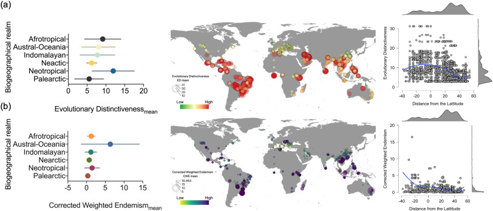

1. [Download : Download high-res image (299KB)](https://ars.els-cdn.com/content/image/1-s2.0-S0048969722040062-gr5_lrg.jpg)
2. [Download : Download full-size image](https://ars.els-cdn.com/content/image/1-s2.0-S0048969722040062-gr5.jpg)

Fig. 5. Comparison of bat cave evolutionary distinctiveness and endemism. (a) Cave Evolutionary Distinctiveness and (b) corrected Weighted endemism compared across biogeographical realms (left). Map of globally-pooled showing the summed ED and CWE of individual caves (right).

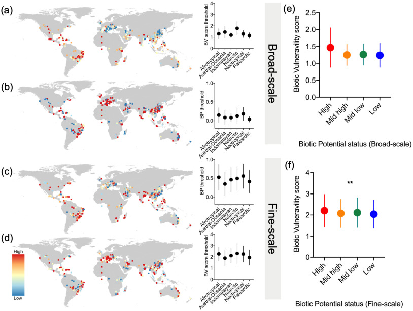

1. [Download : Download high-res image (390KB)](https://ars.els-cdn.com/content/image/1-s2.0-S0048969722040062-gr6_lrg.jpg)
2. [Download : Download full-size image](https://ars.els-cdn.com/content/image/1-s2.0-S0048969722040062-gr6.jpg)

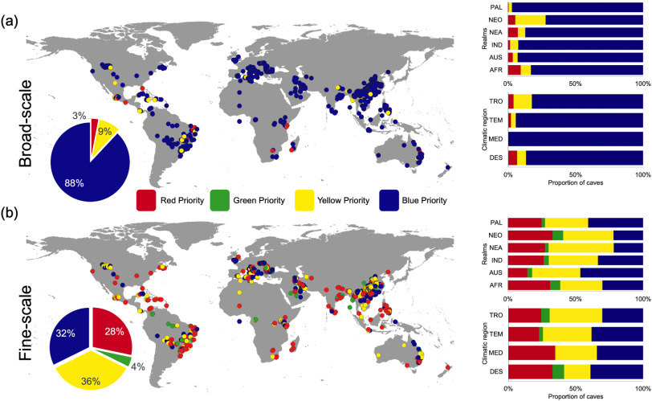

1. [Download : Download high-res image (425KB)](https://ars.els-cdn.com/content/image/1-s2.0-S0048969722040062-gr7_lrg.jpg)
2. [Download : Download full-size image](https://ars.els-cdn.com/content/image/1-s2.0-S0048969722040062-gr7.jpg)

Fig. 7. Global Bat Cave Vulnerability Index and Priorities. (a) Proportion and proportion differences of cave Bat Cave Vulnerability Index- Global (BCVI-G) analysed in broad-scale and fine-scale. The number and percentage of caves according to BCVI-G scales is supplemented in Data S3. Spatial conservation priorities in (b) broad-scale and fine-scale based on Bat Cave Vulnerability Index- Global (BCVI-G). Broad-scale shows poor performance in showing high priority caves compared to fine-scale prioritisation. Proportions are compared across biogeographical realms and [climatic regions](https://www.sciencedirect.com/topics/earth-and-planetary-sciences/climatic-region). Summaries BCVI-G based priorities are being supplemented in Table S6.

Table 2. Proportions differences of cave Global Bat Cave Vulnerability Index (BCVI<sub>global</sub>) analysed in broad-scale and fine-scale. The number and percentage of caves according to BCVI<sub>global</sub> scales is supplemented in Data S3.

| BCVI<sub>global</sub> | Broad-scale | Fine-scale | Proportion difference |
| --- | --- | --- | --- |
| 1A | 0.01 | 0.10 | 0.09 |
| 1B | 0 | 0.11 | 0.11 |
| 1C | 0 | 0.03 | 0.03 |
| 1D | 0 | 0.01 | 0.01 |
| 2A | 0.02 | 0.06 | 0.04 |
| 2B | 0 | 0.06 | 0.06 |
| 2C | 0 | 0.02 | 0.02 |
| 2D | 0 | 0 | 0 |
| 3A | 0.08 | 0.12 | 0.04 |
| 3B | 0 | 0.12 | 0.12 |
| 3C | 0 | 0.04 | 0.04 |
| 3D | 0 | 0 | 0 |
| 4A | 0.83 | 0.17 | −0.66 |
| 4B | 0.05 | 0.12 | 0.07 |
| 4C | 0.01 | 0.03 | 0.02 |
| 4D | 0 | 0 | 0 |

Table 3. Comparison of achieved percent priorities between broad-scale and fine-scale analyses using the Global Bat Cave Vulnerability Index (BCVI<sub>global</sub>). Full data of BCVI<sub>global</sub> results and priorities in two scales are in Data S3 and Table S6.

| Priority-level | Broad-scale | Fine-scale | Global average | Priority difference |
| --- | --- | --- | --- | --- |
| Red | 3 % | 28 % | 15 % | +25 % |
| Green | 0 % | 4 % | 2 % | +4 % |
| Yellow | 9 % | 36 % | 23 % | +27 % |
| Blue | 88 % | 32 % | 60 % | −56 % |

## 4. Discussion

### 4.3. Habitat priorities for conservation

The integration of vulnerability into effective [conservation planning](https://www.sciencedirect.com/topics/earth-and-planetary-sciences/conservation-planning) is often challenging due to vague or inconsistent approaches and definitions (Sarkar et al., 2006). Most habitat prioritisation is widely based on taxonomic diversity (e.g., counts, abundance, and rarity) (Brum et al., 2017; Hartley and Kunin, 2003). Whereas species are often prioritised based on their distinct ecological function, high sensitivity and vulnerability to declines (Mouillot et al., 2013). Within cave ecosystems maintaining cave ecosystem function requires maintaining both diversity and abundance (Bregović et al., 2019; Phelps et al., 2016; Tanalgo et al., 2018), thus a holistic tool that incorporates diversity, rarity and function are needed as a basis for conservation-decision making.

### 4.4. Developing habitat level indices for caves

In our previous work (Tanalgo et al., 2018), we developed the Bat Cave Vulnerable Index (BVCI), but this framework was limited to local and community-level applications. However, whilst such an approach is ideal for a region or country, especially where a single team can inventory all sites, priorities across a broader region require more data that can be collated remotely and can be sourced from multiple teams. Thus the new approach provides an index that can be applied across wide regions, even globally, and like the Essential Biodiversity Variables (EBV's) (Jetz et al., 2019) allows remotely sensed data to be integrated with on the ground data to provide a more robust index for prioritisation. In addition, the integration of species diversity, evolutionary distinctiveness, and threat exposure of both species and their habitat in our vulnerability index enables the prioritisation of cave habitats with rare and higher functional diversity attributes.

For an index to be effective, a clear understanding of diversity patterns and priorities at national levels is an essential first step to implementable policy targets (Doi and Takahara, 2016; Rudd et al., 2011) (Fig. 8). Whilst further data are needed, especially for data-poor, species-rich regions, relying on IUCN Red List data alone risks misleading effective priorities (e.g., [spatial mismatches](https://www.sciencedirect.com/topics/earth-and-planetary-sciences/spatial-mismatch) in the Indomalayan region) (Martín-López et al., 2011; Milner-Gulland et al., 2006). Thus, the IUCN Red List must be utilised alongside other tools and measures of decision-making. Furthermore, habitat-focused indices complement other recent initiatives such as the IUCN Red List of Ecosystems, and the new IUCN ecosystem typology, but also include high-resolution data which can be challenging to include in broader scale indices. Our approach complements the metrics based on geopolitical endemism and conservation status from IUCN which are commonly used within prioritisation schemes (Isaac et al., 2007; Jetz et al., 2014; Martín-López et al., 2009).

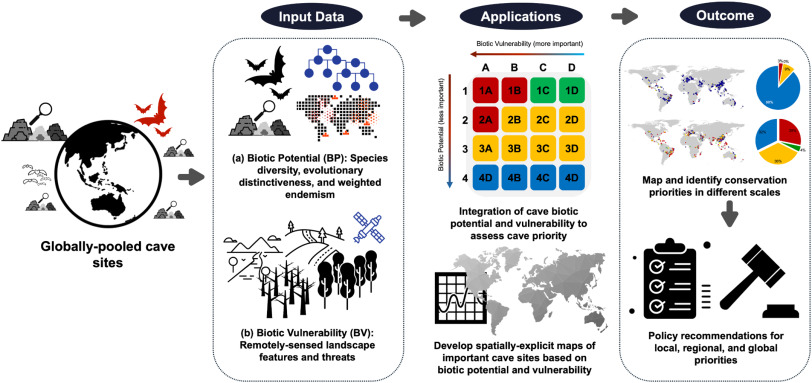

1. [Download : Download high-res image (408KB)](https://ars.els-cdn.com/content/image/1-s2.0-S0048969722040062-gr8_lrg.jpg)
2. [Download : Download full-size image](https://ars.els-cdn.com/content/image/1-s2.0-S0048969722040062-gr8.jpg)

Fig. 8. Framework for prioritising bat caves for conservation. The schematic diagram showing the frame of the Bat Cave Vulnerability Index-Global (BCVI) in identifying and setting priorities for bat caves for conservation on a global scale. The process starts with the pooling of caves sites for assessment assess cave priorities. The input data includes the bat cave diversity (BP) and remotely senses landscape features to assay threats (BV). The index is categorised in four (4) levels with red caves are high priority sites containing the highest diversity and threats and requires immediate conservation actions, while blue caves are the lowest priority sites with the least biodiversity and high to low threat, but no immediate conservation attention is needed.

### 4.5. Caveats and opportunities for bat cave conservation in the Anthropocene

The uneven distribution of threats and a lack of understanding of their impacts remains a challenge for global bat conservation. Developing any index requires pragmatism in finding indicators that are reliable enough, but for which there is sufficient data available. Assessing vulnerability is particularly challenging to identify in the context of cave biota, in which even a single disturbance may alter the entire sensitive biota and ecosystem, yet causal drivers are challenging, and other proximal indicators (e.g., accessibility) must be used as indicators (Cajaiba et al., 2021; De Oliveira et al., 2018; Phelps et al., 2018). Furthermore, the degree of expertise required for bat and cave studies means fewer data are available compared to other taxonomic groups (Herkt et al., 2017; Zamora-Gutierrez et al., 2019). For instance, in our cave prioritisation, we only accounted the 59 % of the global cave-dwelling species, and species coverage varied by region, for example, Indonesia has some of the highest estimated bat cave species richness yet its contribution to the dataset based on surveys and assessments is among the lowest (Tanalgo et al., 2022). In addition, cave community data (e.g., country-level assessments) are lacking for biodiverse regions such as the Afrotropical and Indomalayan regions. Furthermore, accurate systematic and taxonomic studies for bats are vital to appropriate conservation as caves host high endemism and many cave bats (e.g., Rhinolophids) have high numbers of as yet undescribed cryptic species (Mayer et al., 2007; Chornelia et al., 2022). The lack of distribution data may be explicitly linked to the lack of funding in most biodiverse countries (McClanahan and Rankin, 2016), hindering effective assessment in countries most in need. Conversely within Europe, the UNEP-EUROBATS and EU habitats directive provide guidance and regulations, which comprehensively include the protection and monitoring of bats and caves in its territory and member states making parallel and equitable policies for large-scale protection (European Commission, 2021; UNEP/EUROBATS, 2020). Policies and targets that accurately account for and include monitoring in threatened systems such as caves and karsts are urgently needed and highlight a need for ecosystem-based conservation targets, as species-specific targets risk missing key habitats for neglected taxa (Hughes et al., 2021, Hughes et al., 2021; Tanalgo et al., 2022).

Only a few countries have any policy related to the protection of caves and their biota (Medellin et al., 2017; Whitten, 2009). For example, in the Philippines, the National Cave Conservation Committee aims to identify caves for protection has very broad criteria and focused on archaeological and touristic values rather than ecological components which hamper effective protection or priority setting. National Biodiversity Action Plans (NBSAPS) should include standard provisions for priority identification and monitoring which include all habitats (Martín-López et al., 2009), thus frameworks such as this can provide information that is both consistent between countries and can be usefully applied in national levels.

## 5. Conclusions

To protect, sustainably manage and conserve these ecosystems it is crucial that we identify priorities and map vulnerable cave habitats with the highest biodiversity and distinctiveness, as well as those most at risk (Navarro et al., 2017). We illustrate a comprehensive index to integrate facets of diversity and risk to provide a simple and scalable approach to prioritising caves for protection and delineating between those in need of urgent intervention (high diversity but high threat) and those which whilst not yet threatened require monitoring to ensure they remain protected (Fig. 8).

Our study identifies gaps and priorities for bat cave conservation. We highlight just how many high diversity caves are currently threatened (red caves) and those that are currently at low risk but biotically important (green caves), which reflects what form of intervention may be needed for different sites. Maintaining cave bat diversity relies on their inclusion in conservation agendas and priorities, the use of science-based targets and frameworks, and synthesising conservation effectiveness (e.g., Conservation Evidence Initiative (Conservation Evidence, 2021). Ultimately, developing effective decisions requires comparable data and standardised frameworks to enable its translation into policy and practice, such as DarkCideS ([www.darkcides.org](http://www.darkcides.org/)) (Tanalgo et al., 2022). We highlight the power of good data, integration, and the potential for impacts on policy. We hope that with our analysis, and the framework developed here we can begin to use data-driven approaches to help detect and better protect bats and their habitats and that by working collaboratively we can enhance our understanding of bats across the planet.

The following are the supplementary data related to this article.[Download : Download spreadsheet (106KB)](https://ars.els-cdn.com/content/image/1-s2.0-S0048969722040062-mmc1.xlsx)

Data S1. Complete list of cave-dwelling bat species pooled from the International Union for the Conservation of Nature Red List (IUCN Red List) version 2020. The supplementary dataset contains complete taxonomic information, habitat preference, biogeographical range, species distribution, conservation status, endemism, ecological traits, and threatening process.

[Download : Download spreadsheet (45KB)](https://ars.els-cdn.com/content/image/1-s2.0-S0048969722040062-mmc2.xlsx)

Data S2. Country-level species diversity of cave-dwelling bats including estimated species richness, endemism, and proportion of threatened species. The supplementary data also contains the country-level socioecological status including the rate of cement production, forest cover (%), and country Gross Domestic Production (GDP).

[Download : Download spreadsheet (370KB)](https://ars.els-cdn.com/content/image/1-s2.0-S0048969722040062-mmc3.xlsx)

Data S3. Complete list of cave sites and species diversity analysed for prioritisation using Bat Cave Vulnerability Index-Global (BCVI-G). The results of BCVI-G prioritisation in broad-scale and fine-scale are also provided.

[Download : Download Word document (17KB)](https://ars.els-cdn.com/content/image/1-s2.0-S0048969722040062-mmc4.docx)

Table S1. Scoring of species attributes for calculation of cave Biotic Potential (Bp) based on species Population trends (pops), Conservation status (cons), Country endemism (E), and Island endemism (Isl).

[Download : Download Word document (17KB)](https://ars.els-cdn.com/content/image/1-s2.0-S0048969722040062-mmc5.docx)

Table S2. Cave Biotic Potential (BP) priority status and description of the probable scenario. The interpretation of the probable scenario was based on Tanalgo et al., 2018.

[Download : Download Word document (33KB)](https://ars.els-cdn.com/content/image/1-s2.0-S0048969722040062-mmc6.docx)

Table S3. Scoring system for Biotic Vulnerability (BV) index based on the extend of the landscape features and cave probable relative scenario.

[Download : Download Word document (31KB)](https://ars.els-cdn.com/content/image/1-s2.0-S0048969722040062-mmc7.docx)

Table S4. Distribution of cave-dwelling bat species according to families.

[Download : Download Word document (29KB)](https://ars.els-cdn.com/content/image/1-s2.0-S0048969722040062-mmc8.docx)

Table S5. Extinction risks of cave-dwelling bats across different taxonomic and ecological dimensions

[Download : Download Word document (29KB)](https://ars.els-cdn.com/content/image/1-s2.0-S0048969722040062-mmc9.docx)

Table S6. Summary of Binomial Generalised Linear Mixed (GLMs) explaining species extinction risk of (a) global species, and in between suborders (b) Yinpterochiroptera, and (c) Yangochiroptera.

[Download : Download Word document (34KB)](https://ars.els-cdn.com/content/image/1-s2.0-S0048969722040062-mmc10.docx)

Table S7. Summary of threatening process across biogeographical realm and Species Threat Index (SPI) in each ecological dimension.

[Download : Download Word document (32KB)](https://ars.els-cdn.com/content/image/1-s2.0-S0048969722040062-mmc11.docx)

Table S8. Summary statistics of Generalised Linear Models (GLMs) predicting the independent effects of species traits: geographical range, adult body mass, and trophic levels on the vulnerability of species to top threatening process in global scale. Significant predictors were in bold.

[Download : Download Word document (34KB)](https://ars.els-cdn.com/content/image/1-s2.0-S0048969722040062-mmc12.docx)

Table S9. Distribution (cave count) of BCVI<sub>global</sub> in broad-scale and fine-scale across Biogeographical realm and climatic regions.

[Download : Download Word document (1MB)](https://ars.els-cdn.com/content/image/1-s2.0-S0048969722040062-mmc13.docx)

Supplementary Fig. S1. Distribution of global dominant threats (a) and biogeographical patterns (frequency) of threatening process (b) and mean threat index (C). Direct threat is dominant in the Indomalayan region and the greatest threat to 47 % (*N =* 321 spp.; *STI* <sub>*dir*</sub> = 2.15) of the global species. These threats include unregulated tourism (33 %, *N =* 226 spp.), Mining and quarrying (23 %, *N =* 155 spp.), and bushmeat hunting (16 %, *N =* 106 spp.). However, it should be noted that in many tropical regions whilst many species are hunted, it is poorly documented as hunting is for local consumption**.** Indirect threats occurring on the surface threatened 49 % (*N =* 335 spp.; *STI* <sub>*ind*</sub> = 1.60) of the global species primarily from deforestation (42 %, *N =* 284 spp.) and agricultural conversions (23 %, *N =* 155 spp.). Complete threat distribution per species is supplemented in Supplementary Data 1.

[Download : Download Word document (356KB)](https://ars.els-cdn.com/content/image/1-s2.0-S0048969722040062-mmc14.docx)

[Download : Download Word document (58KB)](https://ars.els-cdn.com/content/image/1-s2.0-S0048969722040062-mmc15.docx)

Supplementary methods

## Data accessibility statement

The data which are used in this study have been provided in the supplementary material accompanied by this manuscript.

## CRediT authorship contribution statement

KCT and ACH contributed equally to the work. KCT and ACH conceptualised and designed the study. KCT, HFMO, and ACH collated the data. KCT and ACH integrated, synthesised, and analysed the data. KCT and ACH led the manuscript writing. KCT performed data visualisation. ACH supervised the project. All authors contributed to the editing, reviewing, and approving of the final version of the manuscript.

## Declaration of competing interest

The authors declare that they have no known competing financial interests or personal relationships that could have appeared to influence the work reported in this paper.

## Acknowledgements

We would like to thank the two anonymous reviewers and the editor for their insightful comments that greatly improved the quality of this work. This research paper is part of the Global Bat Cave Vulnerability and Conservation Mapping Initiative project with support from the Chinese National Natural Science Foundation (ACH) (Grant No. U1602265, Mapping Karst Biodiversity in Yunnan), the Strategic Priority Research Program of the Chinese Academy of Sciences (ACH) (Grant No. XDA20050202), the Chinese Academy of Sciences Southeast Asia Biodiversity Research Center fund (ACH) (Grant No. Y4ZK111B01). This work is also part of the Doctoral project of KCT supported by the University of Chinese Academy of Sciences and Chinese Government Scholarship council, P.R. China (CGS No. 2018SLJ023249) and the Zukunftskolleg Connect Fellowship and the Centre for Advanced Study of Collective Behaviour at the University of Konstanz. We also would like to acknowledge the DarkCiDeS consortium (https://darkcides.org/our-team/) for their invaluable contribution to cave data provided in the separate paper which will hopefully provide a key resource to derive studies such as this. We would also like to thank the logistics and field team in XTBG (Ding Zinan, Chen Yanhua, Chen Xing) for support in the elements of the work, and Fu Wuxiang for compiling the data for Chinese caves. We would also like to thank reviewers and editors for their constructive remarks which have improved the paper.

## References

**Amori et al., 2011**

G. Amori, F. Chiozza, C. Rondinini, L. Luiselli

Country-based patterns of total species richness, endemicity, and threatened species richness in African rodents and insectivores

Biodivers. Conserv., 20 (2011), pp. 1225-1237, 10.1007/s10531-011-0024-1

[View in Scopus](https://www.scopus.com/inward/record.url?eid=2-s2.0-79955682433&partnerID=10&rel=R3.0.0)Google Scholar

**Atwood et al., 2020**

T.B. Atwood, S.A. Valentine, E. Hammill, D.J. McCauley, E.M.P. Madin, K.H. Beard, W.D. Pearse

Herbivores at the highest risk of extinction among mammals, birds, and reptiles

Sci. Adv., 6 (2020), Article eabb8458, 10.1126/sciadv.abb8458

[View in Scopus](https://www.scopus.com/inward/record.url?eid=2-s2.0-85089805213&partnerID=10&rel=R3.0.0)Google Scholar

**Aziz et al., 2021**

S.A. Aziz, K. McConkey, K. Tanalgo, T. Sritongchuay, M.-R. Low, J.Y. Yong, T.L. Mildenstein, C.E. Nuevo-Diego, V.-C. Lim, P.A. Racey

The critical importance of Old World fruit bats for healthy ecosystems and economies

Front. Ecol. Evol., 9 (2021), 10.3389/fevo.2021.641411

Google Scholar

**Barclay et al., 2004**

R.M.R. Barclay, J. Ulmer, C.J.A. MacKenzie, M.S. Thompson, L. Olson, J. McCool, E. Cropley, G. Poll

Variation in the reproductive rate of bats

Can. J. Zool., 82 (2004), pp. 688-693, 10.1139/z04-057

[View in Scopus](https://www.scopus.com/inward/record.url?eid=2-s2.0-4544341794&partnerID=10&rel=R3.0.0)Google Scholar

**Bland et al., 2015**

L.M. Bland, B. Collen, C.D.L. Orme, J. Bielby

Predicting the conservation status of data-deficient species

Conserv. Biol., 29 (2015), pp. 250-259, 10.1111/cobi.12372

[View in Scopus](https://www.scopus.com/inward/record.url?eid=2-s2.0-84921436912&partnerID=10&rel=R3.0.0)Google Scholar

**Bregović et al., 2019**

P. Bregović, C. Fišer, M. Zagmajster

Contribution of rare and common species to subterranean species richness patterns

Ecol. Evol., 9 (2019), pp. 11606-11618, 10.1002/ece3.5604

[View in Scopus](https://www.scopus.com/inward/record.url?eid=2-s2.0-85073918972&partnerID=10&rel=R3.0.0)Google Scholar

**Brum et al., 2017**

F.T. Brum, C.H. Graham, G.C. Costa, S.B. Hedges, C. Penone, V.C. Radeloff, C. Rondinini, R. Loyola, A.D. Davidson

Global priorities for conservation across multiple dimensions of mammalian diversity

Proc. Natl. Acad. Sci., 114 (2017), pp. 7641-7646, 10.1073/pnas.1706461114

[View in Scopus](https://www.scopus.com/inward/record.url?eid=2-s2.0-85024388836&partnerID=10&rel=R3.0.0)Google Scholar

**Burgin et al., 2018**

C.J. Burgin, J.P. Colella, P.L. Kahn, N.S. Upham

How many species of mammals are there?

J. Mammal., 99 (2018), pp. 1-14, 10.1093/jmammal/gyx147

[Google Scholar](https://scholar.google.com/scholar?q=How%20many%20species%20of%20mammals%20are%20there)

**Cajaiba et al., 2021**

R.L. Cajaiba, E. Périco, W.B. da Silva, T.B. Vieira, F.M.B. dos Santos, M. Santos

Are neotropical cave-bats good landscape integrity indicators? Some clues when exploring the cross-scale interactions between underground and above-ground ecosystems

Ecol. Indic., 122 (2021), Article 107258, 10.1016/j.ecolind.2020.107258

[View PDF](https://www.sciencedirect.com/science/article/pii/S1470160X20311973/pdfft?md5=b05374f3551e5c9a274cef15e1e0fef9&pid=1-s2.0-S1470160X20311973-main.pdf)[View article](https://www.sciencedirect.com/science/article/pii/S1470160X20311973)[View in Scopus](https://www.scopus.com/inward/record.url?eid=2-s2.0-85099227573&partnerID=10&rel=R3.0.0)Google Scholar

**Cardiff et al., 2009**

S.G. Cardiff, F.H. Ratrimomanarivo, G. Rembert, S.M. Goodman

Hunting, disturbance and roost persistence of bats in caves at ankarana, northern Madagascar

Afr. J. Ecol., 47 (2009), pp. 640-649, 10.1111/j.1365-2028.2008.01015.x

[View in Scopus](https://www.scopus.com/inward/record.url?eid=2-s2.0-73149084173&partnerID=10&rel=R3.0.0)Google Scholar

**Caro, 2010**

T. Caro

Conservation by proxy: Indicator, umbrella, keystone, flagship, and other surrogate species

(2nd edn.), Island Press, Washington, Covelo, London (2010)

[Google Scholar](https://scholar.google.com/scholar_lookup?title=Conservation%20by%20proxy%3A%20Indicator%2C%20umbrella%2C%20keystone%2C%20flagship%2C%20and%20other%20surrogate%20species&publication_year=2010&author=T.%20Caro)

**Ceballos and Ehrlich, 2002**

G. Ceballos, P.R. Ehrlich

Mammal population losses and the extinction crisis

Science, 296 (2002), pp. 904-907, 10.1126/science.1069349

[View in Scopus](https://www.scopus.com/inward/record.url?eid=2-s2.0-0037012826&partnerID=10&rel=R3.0.0)[Google Scholar](https://scholar.google.com/scholar_lookup?title=Mammal%20population%20losses%20and%20the%20extinction%20crisis&publication_year=2002&author=G.%20Ceballos&author=P.R.%20Ehrlich)

**Ceballos et al., 2015**

G. Ceballos, P.R. Ehrlich, A.D. Barnosky, A. García, R.M. Pringle, T.M. Palmer

Accelerated modern human–induced species losses: entering the sixth mass extinction

Sci. Adv., 1 (2015), Article e1400253, 10.1126/sciadv.1400253

[View in Scopus](https://www.scopus.com/inward/record.url?eid=2-s2.0-85024137921&partnerID=10&rel=R3.0.0)[Google Scholar](https://scholar.google.com/scholar?q=Accelerated%20modern%20humaninduced%20species%20losses:%20entering%20the%20sixth%20mass%20extinction)

**Chandra and Idrisova, 2011**

A. Chandra, A. Idrisova

Convention on biological diversity: a review of national challenges and opportunities for implementation

Biodivers. Conserv., 20 (2011), pp. 3295-3316, 10.1007/s10531-011-0141-x

[View in Scopus](https://www.scopus.com/inward/record.url?eid=2-s2.0-81555205768&partnerID=10&rel=R3.0.0)Google Scholar

**Chornelia et al., 2022**

A. Chornelia, J. Lu, A.C. Hughes

How to accurately delineate morphologically conserved taxa and diagnose their phenotypic disparities: species delimitation in cryptic rhinolophidae (Chiroptera)

Front. Ecol. Evol., 10 (2022), pp. 1-18, 10.3389/fevo.2022.854509

Google Scholar

**Clark and May, 2002**

J.A. Clark, R.M. May

Taxonomic bias in conservation research

Science, 297 (2002), pp. 191-192, 10.1126/science.297.5579.191b

[Google Scholar](https://scholar.google.com/scholar_lookup?title=Taxonomic%20bias%20in%20conservation%20research&publication_year=2002&author=J.A.%20Clark&author=R.M.%20May)

**Clements et al., 2006**

R. Clements, N.S. Sodhi, M. Schilthuizen, P.K.L. Ng

Limestone karsts of Southeast Asia: imperiled arks of biodiversity

Bioscience, 56 (2006), pp. 733-742, 10.1641/0006-3568(2006)56[733:LKOSAI]2.0.CO;2

[View in Scopus](https://www.scopus.com/inward/record.url?eid=2-s2.0-33748476251&partnerID=10&rel=R3.0.0)Google Scholar

**Commission, 2021**

European Commission

The habitats directive - environment - European Commission [WWW Document]

https://ec.europa.eu/environment/nature/legislation/habitatsdirective/index_en.htm (2021)

accessed 8.5.21

[Google Scholar](https://scholar.google.com/scholar?q=The%20habitats%20directive%20-%20environment%20-%20European%20Commission%20WWW%20Document)

**Conenna et al., 2017**

I. Conenna, R. Rocha, D. Russo, M. Cabeza

Insular bats and research effort: a review of global patterns and priorities

Mammal Rev., 47 (2017), pp. 169-182, 10.1111/mam.12090

[View in Scopus](https://www.scopus.com/inward/record.url?eid=2-s2.0-85017542226&partnerID=10&rel=R3.0.0)Google Scholar

**Conservaton Evidence, 2021**

Conservaton Evidence

Conservation Evidence: Evidence Data

[WWW Document]

(2021)

URL https://www.conservationevidence.com/data/index/?synopsis_id=14 (accessed 3.23.21)

[Google Scholar](https://scholar.google.com/scholar_lookup?title=Conservation%20Evidence%3A%20Evidence%20Data&publication_year=2021&author=Conservaton%20Evidence)

**Cowie et al., 2017**

R. Cowie, C. Régnier, B. Fontaine, P. Bouchet

Measuring the sixth extinction: what do mollusks tell us?

The Nautilus, 131 (2017), pp. 3-41

[View in Scopus](https://www.scopus.com/inward/record.url?eid=2-s2.0-85019251983&partnerID=10&rel=R3.0.0)[Google Scholar](https://scholar.google.com/scholar?q=Measuring%20the%20sixth%20extinction:%20what%20do%20mollusks%20tell%20us)

**Crisp et al., 2001**

M.D. Crisp, S. Laffan, H.P. Linder, A. Monro

Endemism in the australian flora

J. Biogeogr., 28 (2001), pp. 183-198, 10.1046/j.1365-2699.2001.00524.x

[View in Scopus](https://www.scopus.com/inward/record.url?eid=2-s2.0-0034968984&partnerID=10&rel=R3.0.0)[Google Scholar](https://scholar.google.com/scholar_lookup?title=Endemism%20in%20the%20australian%20flora&publication_year=2001&author=M.D.%20Crisp&author=S.%20Laffan&author=H.P.%20Linder&author=A.%20Monro)

**Cunha et al., 2020**

A.O.B. Cunha, J.D.P. Bezerra, T.G.L. Oliveira, E. Barbier, E. Bernard, A.R. Machado, C.M. Souza-Motta

Living in the dark: bat caves as hotspots of fungal diversity

PLoS ONE, 15 (2020), Article e0243494, 10.1371/journal.pone.0243494

[View in Scopus](https://www.scopus.com/inward/record.url?eid=2-s2.0-85097311419&partnerID=10&rel=R3.0.0)Google Scholar

**Day and Urich, 2000**

M. Day, P. Urich

An assessment of protected karst landscapes in Southeast Asia

Cave Karst Sci., 27 (2000), pp. 61-70

[View in Scopus](https://www.scopus.com/inward/record.url?eid=2-s2.0-0034466335&partnerID=10&rel=R3.0.0)[Google Scholar](https://scholar.google.com/scholar_lookup?title=An%20assessment%20of%20protected%20karst%20landscapes%20in%20Southeast%20Asia&publication_year=2000&author=M.%20Day&author=P.%20Urich)

**De Oliveira et al., 2018**

H.F.M. De Oliveira, M. Oprea, R.I. Dias

Distributional patterns and ecological determinants of bat occurrence inside caves: a broad scale meta-analysis

Diversity, 10 (2018), p. 49, 10.3390/d10030049

[View in Scopus](https://www.scopus.com/inward/record.url?eid=2-s2.0-85053767368&partnerID=10&rel=R3.0.0)Google Scholar

**Deharveng and Bedos, 2018**

L. Deharveng, A. Bedos

Diversity of terrestrial invertebrates in Subterranean habitats

O.T. Moldovan, Ľ. Kováč, S. Halse (Eds.), Cave Ecology, Ecological Studies, Springer International Publishing, Cham (2018), pp. 107-172, 10.1007/978-3-319-98852-8_7

[View in Scopus](https://www.scopus.com/inward/record.url?eid=2-s2.0-85065228567&partnerID=10&rel=R3.0.0)[Google Scholar](https://scholar.google.com/scholar_lookup?title=Diversity%20of%20terrestrial%20invertebrates%20in%20Subterranean%20habitats&publication_year=2018&author=L.%20Deharveng&author=A.%20Bedos)

**Doi and Takahara, 2016**

H. Doi, T. Takahara

Global patterns of conservation research importance in different countries of the world

PeerJ, 4 (2016), Article e2173, 10.7717/peerj.2173

[View in Scopus](https://www.scopus.com/inward/record.url?eid=2-s2.0-84981484511&partnerID=10&rel=R3.0.0)Google Scholar

**Dolman et al., 2012**

P.M. Dolman, C.J. Panter, H.L. Mossman

The biodiversity audit approach challenges regional priorities and identifies a mismatch in conservation

J. Appl. Ecol., 49 (2012), pp. 986-997, 10.1111/j.1365-2664.2012.02174.x

[View in Scopus](https://www.scopus.com/inward/record.url?eid=2-s2.0-84866526583&partnerID=10&rel=R3.0.0)Google Scholar

**Ellis et al., 2013**

E.C. Ellis, J.O. Kaplan, D.Q. Fuller, S. Vavrus, K.K. Goldewijk, P.H. Verburg

Used planet: a global history

Proc. Natl. Acad. Sci., 110 (2013), pp. 7978-7985, 10.1073/pnas.1217241110

[View in Scopus](https://www.scopus.com/inward/record.url?eid=2-s2.0-84877851710&partnerID=10&rel=R3.0.0)Google Scholar

**Etard et al., 2020**

A. Etard, S. Morrill, T. Newbold

Global gaps in trait data for terrestrial vertebrates

Glob. Ecol. Biogeogr., 29 (2020), pp. 2143-2158, 10.1111/geb.13184

[View in Scopus](https://www.scopus.com/inward/record.url?eid=2-s2.0-85092374228&partnerID=10&rel=R3.0.0)[Google Scholar](https://scholar.google.com/scholar_lookup?title=Global%20gaps%20in%20trait%20data%20for%20terrestrial%20vertebrates&publication_year=2020&author=A.%20Etard&author=S.%20Morrill&author=T.%20Newbold)

**Faurby et al., 2018**

S. Faurby, M. Davis, R.Ø. Pedersen, S.D. Schowanek, A. Antonelli, J.-C. Svenning

PHYLACINE 1.2: the phylogenetic atlas of mammal macroecology

Ecology, 99 (2018), p. 2626, 10.1002/ecy.2443

[View in Scopus](https://www.scopus.com/inward/record.url?eid=2-s2.0-85054305452&partnerID=10&rel=R3.0.0)Google Scholar

**Ferreira, 2019**

R.L. Ferreira

Chapter 57 - guano communities

W.B. White, D.C. Culver, T. Pipan (Eds.), Encyclopedia of Caves (Third edition), Academic Press (2019), pp. 474-484, 10.1016/B978-0-12-814124-3.00057-1

[View PDF](https://www.sciencedirect.com/science/article/pii/B9780128141243000571/pdfft?md5=9f304c6dfab2a42caf8540f9874f9a5c&pid=3-s2.0-B9780128141243000571-main.pdf)[View article](https://www.sciencedirect.com/science/article/pii/B9780128141243000571)[View in Scopus](https://www.scopus.com/inward/record.url?eid=2-s2.0-85077335194&partnerID=10&rel=R3.0.0)[Google Scholar](https://scholar.google.com/scholar_lookup?title=Chapter%2057%20-%20guano%20communities&publication_year=2019&author=R.L.%20Ferreira)

**Ferreira and Martins, 1999**

R.L. Ferreira, R.P. Martins

Trophic structure and natural history of bat guano invertebrate communities, with special reference to Brazilian caves

Trop. Zool., 12 (1999), pp. 231-252, 10.1080/03946975.1999.10539391

[View in Scopus](https://www.scopus.com/inward/record.url?eid=2-s2.0-0033269958&partnerID=10&rel=R3.0.0)Google Scholar

**Ficetola et al., 2019**

G.F. Ficetola, C. Canedoli, F. Stoch

The racovitzan impediment and the hidden biodiversity of unexplored environments

Conserv. Biol., 33 (2019), pp. 214-216, 10.1111/cobi.13179

[View in Scopus](https://www.scopus.com/inward/record.url?eid=2-s2.0-85053253910&partnerID=10&rel=R3.0.0)Google Scholar

**Fleming and Bateman, 2016**

P.A. Fleming, P.W. Bateman

The good, the bad, and the ugly: which australian terrestrial mammal species attract most research?

Mammal Rev., 46 (2016), pp. 241-254, 10.1111/mam.12066

[View in Scopus](https://www.scopus.com/inward/record.url?eid=2-s2.0-84960154947&partnerID=10&rel=R3.0.0)[Google Scholar](https://scholar.google.com/scholar?q=The%20good,%20the%20bad,%20and%20the%20ugly:%20which%20australian%20terrestrial%20mammal%20species%20attract%20most%20research)

**Ford et al., 2017**

A.T. Ford, S.J. Cooke, J.R. Goheen, T.P. Young

Conserving megafauna or sacrificing biodiversity?

Bioscience, 67 (2017), pp. 193-196, 10.1093/biosci/biw163

[View in Scopus](https://www.scopus.com/inward/record.url?eid=2-s2.0-85019915497&partnerID=10&rel=R3.0.0)[Google Scholar](https://scholar.google.com/scholar?q=Conserving%20megafauna%20or%20sacrificing%20biodiversity)

**Francis et al., 2010**

C.M. Francis, A.V. Borisenko, N.V. Ivanova, J.L. Eger, B.K. Lim, A. Guillén-Servent, S.V. Kruskop, I. Mackie, P.D.N. Hebert

The role of DNA barcodes in understanding and conservation of mammal diversity in Southeast Asia

PLOS ONE, 5 (2010), Article e12575, 10.1371/journal.pone.0012575

Google Scholar

**Frick et al., 2019**

W.F. Frick, T. Kingston, J. Flanders

A review of the major threats and challenges to global bat conservation

Ann. N. Y. Acad. Sci., 1469 (2019), pp. 5-25, 10.1111/nyas.14045

[View in Scopus](https://www.scopus.com/inward/record.url?eid=2-s2.0-85069503697&partnerID=10&rel=R3.0.0)Google Scholar

**Fritz et al., 2009**

S.A. Fritz, O.R.P. Bininda-Emonds, A. Purvis

Geographical variation in predictors of mammalian extinction risk: big is bad, but only in the tropics

Ecol. Lett., 12 (2009), pp. 538-549, 10.1111/j.1461-0248.2009.01307.x

[View in Scopus](https://www.scopus.com/inward/record.url?eid=2-s2.0-65749102640&partnerID=10&rel=R3.0.0)Google Scholar

**Furey and Racey, 2016**

N.M. Furey, P.A. Racey

Conservation ecology of cave bats

C.C. Voigt, T. Kingston (Eds.), Bats in the Anthropocene: Conservation of Bats in a Changing World, Springer International Publishing, Cham (2016), pp. 463-500, 10.1007/978-3-319-25220-9_15

[View in Scopus](https://www.scopus.com/inward/record.url?eid=2-s2.0-85120329725&partnerID=10&rel=R3.0.0)[Google Scholar](https://scholar.google.com/scholar_lookup?title=Conservation%20ecology%20of%20cave%20bats&publication_year=2016&author=N.M.%20Furey&author=P.A.%20Racey)

**Gallucci, 2019**

M. Gallucci

GAMLj: General Analyses for Linear Models.[jamovi module]. Version

(2019)

[Google Scholar](https://scholar.google.com/scholar?q=GAMLj:%20General%20Analyses%20for%20Linear%20Models.jamovi%20module.%20Version)

**Goodman, 2006**

S.M. Goodman

Hunting of microchiroptera in South-Western Madagascar

Oryx, 40 (2006), pp. 225-228, 10.1017/S0030605306000354

[View in Scopus](https://www.scopus.com/inward/record.url?eid=2-s2.0-33749125862&partnerID=10&rel=R3.0.0)[Google Scholar](https://scholar.google.com/scholar_lookup?title=Hunting%20of%20microchiroptera%20in%20South-Western%20Madagascar&publication_year=2006&author=S.M.%20Goodman)

**Gordon et al., 2019**

E.R. Gordon, N. Butt, H. Rosner-Katz, A.D. Binley, J.R. Bennett

Relative costs of conserving threatened species across taxonomic groups

Conserv. Biol. (2019), 10.1111/cobi.13382

Google Scholar

**Halpern et al., 2006**

B.S. Halpern, C.R. Pyke, H.E. Fox, J.C. Haney, M.A. Schlaepfer, P. Zaradic

Gaps and mismatches between global conservation priorities and spending

Conserv. Biol., 20 (2006), pp. 56-64, 10.1111/j.1523-1739.2005.00258.x

[View in Scopus](https://www.scopus.com/inward/record.url?eid=2-s2.0-33645023397&partnerID=10&rel=R3.0.0)Google Scholar

**Hammer et al., 2001**

Ø. Hammer, D. Harper, P. Ryan

PAST: paleontological statistics software package for education and data analysis

Palaeontol. Electron., 4 (2001)

Google Scholar

**Hartley and Kunin, 2003**

S. Hartley, W.E. Kunin

Scale dependency of rarity, extinction risk, and conservation priority

Conserv. Biol., 17 (2003), pp. 1559-1570, 10.1111/j.1523-1739.2003.00015.x

[View in Scopus](https://www.scopus.com/inward/record.url?eid=2-s2.0-0347473813&partnerID=10&rel=R3.0.0)[Google Scholar](https://scholar.google.com/scholar_lookup?title=Scale%20dependency%20of%20rarity%2C%20extinction%20risk%2C%20and%20conservation%20priority&publication_year=2003&author=S.%20Hartley&author=W.E.%20Kunin)

**Herkt et al., 2017**

K.M.B. Herkt, A.K. Skidmore, J. Fahr

Macroecological conclusions based on IUCN expert maps: a call for caution

Glob. Ecol. Biogeogr., 26 (2017), pp. 930-941, 10.1111/geb.12601

[View in Scopus](https://www.scopus.com/inward/record.url?eid=2-s2.0-85023183853&partnerID=10&rel=R3.0.0)Google Scholar

**Hernández-Quiroz et al., 2018**

N.S. Hernández-Quiroz, E.I. Badano, F. Barragán-Torres, J. Flores, C. Pinedo-Álvarez

Habitat suitability models to make conservation decisions based on areas of high species richness and endemism

Biodivers. Conserv., 27 (2018), pp. 3185-3200, 10.1007/s10531-018-1596-9

[View in Scopus](https://www.scopus.com/inward/record.url?eid=2-s2.0-85050677478&partnerID=10&rel=R3.0.0)Google Scholar

**Hoffmann et al., 2010**

The impact of conservation on the status of the world'’s vertebrates

Science, 330 (2010), pp. 1503-1509, 10.1126/science.1194442

[View in Scopus](https://www.scopus.com/inward/record.url?eid=2-s2.0-78650169956&partnerID=10&rel=R3.0.0)[Google Scholar](https://scholar.google.com/scholar?q=The%20impact%20of%20conservation%20on%20the%20status%20of%20the%20worlds%20vertebrates)

**Hughes et al., 2021**

A. Hughes, M. Orr, Q. Yang, H. Qiao

Effectively and accurately mapping global biodiversity patterns for different regions and taxa

Glob. Ecol. Biogeogr. (2021), 10.22541/au.159654424.40253314

Google Scholar

**Hughes, 2017**

A.C. Hughes

Understanding the drivers of southeast asian biodiversity loss

Ecosphere, 8 (2017), Article e01624, 10.1002/ecs2.1624

[Google Scholar](https://scholar.google.com/scholar_lookup?title=Understanding%20the%20drivers%20of%20southeast%20asian%20biodiversity%20loss&publication_year=2017&author=A.C.%20Hughes)

**Hughes, 2019**

A.C. Hughes

Understanding and minimizing environmental impacts of the belt and road initiative

Conserv. Biol., 33 (2019), pp. 883-894, 10.1111/cobi.13317

[View in Scopus](https://www.scopus.com/inward/record.url?eid=2-s2.0-85064047670&partnerID=10&rel=R3.0.0)[Google Scholar](https://scholar.google.com/scholar_lookup?title=Understanding%20and%20minimizing%20environmental%20impacts%20of%20the%20belt%20and%20road%20initiative&publication_year=2019&author=A.C.%20Hughes)

**Hughes et al., 2021**

A.C. Hughes, H. Qiao, M.C. Orr

Extinction targets are not SMART (Specific, measurable, ambitious, realistic, and time Bound)

Bioscience, 71 (2021), pp. 115-118, 10.1093/biosci/biaa148

[View in Scopus](https://www.scopus.com/inward/record.url?eid=2-s2.0-85104934077&partnerID=10&rel=R3.0.0)[Google Scholar](https://scholar.google.com/scholar?q=Extinction%20targets%20are%20not%20SMART)

**Isaac et al., 2007**

N.J.B. Isaac, S.T. Turvey, B. Collen, C. Waterman, J.E.M. Baillie

Mammals on the EDGE: conservation priorities based on threat and phylogeny

PLoS ONE, 2 (2007), Article e296, 10.1371/journal.pone.0000296

[View in Scopus](https://www.scopus.com/inward/record.url?eid=2-s2.0-55849110019&partnerID=10&rel=R3.0.0)Google Scholar

**Jetz et al., 2014**

W. Jetz, G.H. Thomas, J.B. Joy, D.W. Redding, K. Hartmann, A.O. Mooers

Global distribution and conservation of evolutionary distinctness in birds

Curr. Biol., 24 (2014), pp. 919-930, 10.1016/j.cub.2014.03.011

[View PDF](https://www.sciencedirect.com/science/article/pii/S096098221400270X/pdfft?md5=6ea6983b73bfb5a03ba699ce0180eab9&pid=1-s2.0-S096098221400270X-main.pdf)[View article](https://www.sciencedirect.com/science/article/pii/S096098221400270X)[View in Scopus](https://www.scopus.com/inward/record.url?eid=2-s2.0-84899923627&partnerID=10&rel=R3.0.0)Google Scholar

**Jetz et al., 2019**

W. Jetz, M.A. McGeoch, R. Guralnick, S. Ferrier, J. Beck, M.J. Costello, M. Fernandez, G.N. Geller, P. Keil, C. Merow, C. Meyer, F.E. Muller-Karger, H.M. Pereira, E.C. Regan, D.S. Schmeller, E. Turak

Essential biodiversity variables for mapping and monitoring species populations

Nat. Ecol. Evol., 3 (2019), pp. 539-551, 10.1038/s41559-019-0826-1

[View in Scopus](https://www.scopus.com/inward/record.url?eid=2-s2.0-85062817491&partnerID=10&rel=R3.0.0)Google Scholar

**Jones et al., 2009**

G. Jones, D.S. Jacobs, T.H. Kunz, M.R. Willig, P.A. Racey

Carpe noctem: the importance of bats as bioindicators

Endanger. Species Res., 8 (2009), pp. 93-115, 10.3354/esr00182

[View in Scopus](https://www.scopus.com/inward/record.url?eid=2-s2.0-68149089843&partnerID=10&rel=R3.0.0)Google Scholar

**Jones et al., 2003**

K.E. Jones, A. Purvis, J.L. Gittleman

Biological correlates of extinction risk in bats

Am. Nat., 161 (2003), pp. 601-614, 10.1086/368289

[View in Scopus](https://www.scopus.com/inward/record.url?eid=2-s2.0-0037398718&partnerID=10&rel=R3.0.0)[Google Scholar](https://scholar.google.com/scholar_lookup?title=Biological%20correlates%20of%20extinction%20risk%20in%20bats&publication_year=2003&author=K.E.%20Jones&author=A.%20Purvis&author=J.L.%20Gittleman)

**Joseph et al., 2009**

L.N. Joseph, R.F. Maloney, H.P. Possingham

Optimal allocation of resources among threatened species: a project prioritization protocol

Conserv. Biol., 23 (2009), pp. 328-338, 10.1111/j.1523-1739.2008.01124.x

[View in Scopus](https://www.scopus.com/inward/record.url?eid=2-s2.0-62549130267&partnerID=10&rel=R3.0.0)Google Scholar

**Laffan and Crisp, 2003**

S.W. Laffan, M.D. Crisp

Assessing endemism at multiple spatial scales, with an example from the australian vascular flora

J. Biogeogr., 30 (2003), pp. 511-520, 10.1046/j.1365-2699.2003.00875.x

[View in Scopus](https://www.scopus.com/inward/record.url?eid=2-s2.0-0038701959&partnerID=10&rel=R3.0.0)Google Scholar

**Lewandowski et al., 2010**

A.S. Lewandowski, R.F. Noss, D.R. Parsons

The effectiveness of surrogate taxa for the representation of biodiversity

Conserv. Biol., 24 (2010), pp. 1367-1377, 10.1111/j.1523-1739.2010.01513.x

[View in Scopus](https://www.scopus.com/inward/record.url?eid=2-s2.0-77957167848&partnerID=10&rel=R3.0.0)Google Scholar

**Liew et al., 2016**

T.-S. Liew, L. Price, G.R. Clements

Using Google earth to improve the Management of Threatened Limestone Karst Ecosystems in peninsular Malaysia

Trop. Conserv. Sci., 9 (2016), pp. 903-920, 10.1177/194008291600900219

[View in Scopus](https://www.scopus.com/inward/record.url?eid=2-s2.0-84976428078&partnerID=10&rel=R3.0.0)Google Scholar

**Lindenmayer and Westgate, 2020**

D.B. Lindenmayer, M.J. Westgate

Are flagship, umbrella and keystone species useful surrogates to understand the consequences of landscape change?

Curr. Landsc. Ecol. Rep., 5 (2020), pp. 76-84, 10.1007/s40823-020-00052-x

[View in Scopus](https://www.scopus.com/inward/record.url?eid=2-s2.0-85103175592&partnerID=10&rel=R3.0.0)[Google Scholar](https://scholar.google.com/scholar?q=Are%20flagship,%20umbrella%20and%20keystone%20species%20useful%20surrogates%20to%20understand%20the%20consequences%20of%20landscape%20change)

**Mammola et al., 2019**

S. Mammola, P. Cardoso, D.C. Culver, L. Deharveng, R.L. Ferreira, C. Fišer, D.M.P. Galassi, C. Griebler, S. Halse, W.F. Humphreys, M. Isaia, F. Malard, A. Martinez, O.T. Moldovan, M.L. Niemiller, M. Pavlek, A.S.P.S. Reboleira, M. Souza-Silva, E.C. Teeling, J.J. Wynne, M. Zagmajster

Scientists’ warning on the conservation of subterranean ecosystems

Bioscience (2019), 10.1093/biosci/biz064

[Google Scholar](https://scholar.google.com/scholar?q=Scientists%20warning%20on%20the%20conservation%20of%20subterranean%20ecosystems)

**Mammola et al., 2021**

S. Mammola, E. Lunghi, H. Bilandžija, P. Cardoso, V. Grimm, S.I. Schmidt, T. Hesselberg, A. Martínez

Collecting eco-evolutionary data in the dark: impediments to subterranean research and how to overcome them

Ecol. Evol., 11 (2021), pp. 5911-5926, 10.1002/ece3.7556

[View in Scopus](https://www.scopus.com/inward/record.url?eid=2-s2.0-85105158453&partnerID=10&rel=R3.0.0)Google Scholar

**Manenti et al., 2018**

R. Manenti, B. Barzaghi, E. Lana, G.A. Stocchino, R. Manconi, E. Lunghi

The stenoendemic cave-dwelling planarians (Platyhelminthes, Tricladida) of the italian Alps and apennines: conservation issues

J. Nat. Conserv., 45 (2018), pp. 90-97, 10.1016/j.jnc.2018.08.001

[View PDF](https://www.sciencedirect.com/science/article/pii/S1617138118301493/pdfft?md5=2c419f13b8e86d08a8617f3f483e85c6&pid=1-s2.0-S1617138118301493-main.pdf)[View article](https://www.sciencedirect.com/science/article/pii/S1617138118301493)[View in Scopus](https://www.scopus.com/inward/record.url?eid=2-s2.0-85051948177&partnerID=10&rel=R3.0.0)[Google Scholar](https://scholar.google.com/scholar?q=The%20stenoendemic%20cave-dwelling%20planarians%20%20of%20the%20italian%20Alps%20and%20apennines:%20conservation%20issues)

**Margules et al., 2002**

C.R. Margules, R.L. Pressey, P.H. Williams

Representing biodiversity: data and procedures for identifying priority areas for conservation

J. Biosci., 27 (2002), pp. 309-326, 10.1007/BF02704962

[View in Scopus](https://www.scopus.com/inward/record.url?eid=2-s2.0-0035988562&partnerID=10&rel=R3.0.0)Google Scholar

**Martín-López et al., 2009**

B. Martín-López, C. Montes, L. Ramírez, J. Benayas

What drives policy decision-making related to species conservation?

Biol. Conserv., 142 (2009), pp. 1370-1380, 10.1016/j.biocon.2009.01.030

[View PDF](https://www.sciencedirect.com/science/article/pii/S000632070900069X/pdfft?md5=2946578507dd2871d2010f03ea0de5a6&pid=1-s2.0-S000632070900069X-mainext.pdf)[View article](https://www.sciencedirect.com/science/article/pii/S000632070900069X)[View in Scopus](https://www.scopus.com/inward/record.url?eid=2-s2.0-67349267759&partnerID=10&rel=R3.0.0)[Google Scholar](https://scholar.google.com/scholar?q=What%20drives%20policy%20decision-making%20related%20to%20species%20conservation)

**Martín-López et al., 2011**

B. Martín-López, J.A. González, C. Montes

The pitfall-trap of species conservation priority setting

Biodivers. Conserv., 20 (2011), pp. 663-682, 10.1007/s10531-010-9973-z

[View in Scopus](https://www.scopus.com/inward/record.url?eid=2-s2.0-79951773015&partnerID=10&rel=R3.0.0)Google Scholar

**Mayer et al., 2007**

F. Mayer, C. Dietz, A. Kiefer

Molecular species identification boosts bat diversity

Front. Zool., 4 (2007), p. 4, 10.1186/1742-9994-4-4

[View in Scopus](https://www.scopus.com/inward/record.url?eid=2-s2.0-33847256461&partnerID=10&rel=R3.0.0)[Google Scholar](https://scholar.google.com/scholar_lookup?title=Molecular%20species%20identification%20boosts%20bat%20diversity&publication_year=2007&author=F.%20Mayer&author=C.%20Dietz&author=A.%20Kiefer)

**McClanahan and Rankin, 2016**

T.R. McClanahan, P.S. Rankin

Geography of conservation spending, biodiversity, and culture

Conserv. Biol., 30 (2016), pp. 1089-1101, 10.1111/cobi.12720

[View in Scopus](https://www.scopus.com/inward/record.url?eid=2-s2.0-85027937453&partnerID=10&rel=R3.0.0)[Google Scholar](https://scholar.google.com/scholar_lookup?title=Geography%20of%20conservation%20spending%2C%20biodiversity%2C%20and%20culture&publication_year=2016&author=T.R.%20McClanahan&author=P.S.%20Rankin)

**McClure et al., 2020**

M.L. McClure, D. Crowley, C.G. Haase, L.P. McGuire, N.W. Fuller, D.T.S. Hayman, C.L. Lausen, R.K. Plowright, B.G. Dickson, S.H. Olson

Linking surface and subterranean climate: implications for the study of hibernating bats and other cave dwellers

Ecosphere, 11 (2020), Article e03274, 10.1002/ecs2.3274

[View in Scopus](https://www.scopus.com/inward/record.url?eid=2-s2.0-85094640265&partnerID=10&rel=R3.0.0)Google Scholar

**McGeoch et al., 2010**

M.A. McGeoch, S.H.M. Butchart, D. Spear, E. Marais, E.J. Kleynhans, A. Symes, J. Chanson, M. Hoffmann

Global indicators of biological invasion: species numbers, biodiversity impact and policy responses

Divers. Distrib., 16 (2010), pp. 95-108, 10.1111/j.1472-4642.2009.00633.x

[View in Scopus](https://www.scopus.com/inward/record.url?eid=2-s2.0-74549115840&partnerID=10&rel=R3.0.0)Google Scholar

**Medellin et al., 2017**

R.A. Medellin, R. Wiederholt, L. Lopez-Hoffman

Conservation relevance of bat caves for biodiversity and ecosystem services

Biol. ConservSmall Natural Features, 211 (2017), pp. 45-50, 10.1016/j.biocon.2017.01.012

[View PDF](https://www.sciencedirect.com/science/article/pii/S0006320717301088/pdfft?md5=fea0bf9e92c4254a9f103e18f33f442a&pid=1-s2.0-S0006320717301088-main.pdf)[View article](https://www.sciencedirect.com/science/article/pii/S0006320717301088)[View in Scopus](https://www.scopus.com/inward/record.url?eid=2-s2.0-85011031983&partnerID=10&rel=R3.0.0)Google Scholar

**Mickleburgh et al., 2009**

S. Mickleburgh, K. Waylen, P. Racey

Bats as bushmeat: a global review

Oryx, 43 (2009), pp. 217-234, 10.1017/S0030605308000938

[View in Scopus](https://www.scopus.com/inward/record.url?eid=2-s2.0-68149126927&partnerID=10&rel=R3.0.0)[Google Scholar](https://scholar.google.com/scholar_lookup?title=Bats%20as%20bushmeat%3A%20a%20global%20review&publication_year=2009&author=S.%20Mickleburgh&author=K.%20Waylen&author=P.%20Racey)

**Mildenstein et al., 2016**

T. Mildenstein, I. Tanshi, P.A. Racey

Exploitation of bats for bushmeat and medicine

C.C. Voigt, T. Kingston (Eds.), Bats in the Anthropocene: Conservation of Bats in a Changing World, Springer International Publishing, Cham (2016), pp. 325-375, 10.1007/978-3-319-25220-9_12

[View in Scopus](https://www.scopus.com/inward/record.url?eid=2-s2.0-85045267281&partnerID=10&rel=R3.0.0)[Google Scholar](https://scholar.google.com/scholar_lookup?title=Exploitation%20of%20bats%20for%20bushmeat%20and%20medicine&publication_year=2016&author=T.%20Mildenstein&author=I.%20Tanshi&author=P.A.%20Racey)

**Milner-Gulland et al., 2006**

E.J. Milner-Gulland, E. Kreuzberg-Mukhina, B. Grebot, S. Ling, E. Bykova, I. Abdusalamov, A. Bekenov, U. Gärdenfors, C. Hilton-Taylor, V. Salnikov, L. Stogova

Application of IUCN red listing criteria at the regional and National Levels: a case study from Central Asia

Biodivers. Conserv., 15 (2006), pp. 1873-1886, 10.1007/s10531-005-4304-5

[View in Scopus](https://www.scopus.com/inward/record.url?eid=2-s2.0-33745790758&partnerID=10&rel=R3.0.0)Google Scholar

**Mouillot et al., 2013**

D. Mouillot, D.R. Bellwood, C. Baraloto, J. Chave, R. Galzin, M. Harmelin-Vivien, M. Kulbicki, S. Lavergne, S. Lavorel, N. Mouquet, C.E.T. Paine, J. Renaud, W. Thuiller

Rare species support vulnerable functions in high-diversity ecosystems

PLoS Biol., 11 (2013), Article e1001569, 10.1371/journal.pbio.1001569

[View in Scopus](https://www.scopus.com/inward/record.url?eid=2-s2.0-84878266956&partnerID=10&rel=R3.0.0)Google Scholar

**Murray et al., 2012**

S.W. Murray, P. Campbell, T. Kingston, A. Zubaid, C.M. Francis, T.H. Kunz

Molecular phylogeny of hipposiderid bats from Southeast Asia and evidence of cryptic diversity

Mol. Phylogenet. Evol., 62 (2012), pp. 597-611, 10.1016/j.ympev.2011.10.021

[View PDF](https://www.sciencedirect.com/science/article/pii/S1055790311004532/pdfft?md5=0d488e51e88f0df2f17cb1b133dbd153&pid=1-s2.0-S1055790311004532-main.pdf)[View article](https://www.sciencedirect.com/science/article/pii/S1055790311004532)[View in Scopus](https://www.scopus.com/inward/record.url?eid=2-s2.0-84855193892&partnerID=10&rel=R3.0.0)Google Scholar

**Navarro et al., 2017**

L.M. Navarro, N. Fernández, C. Guerra, R. Guralnick, W.D. Kissling, M.C. Londoño, H.M. Pereira

Monitoring biodiversity change through effective global coordination

Curr. Opin. Environ. Sustain., 29 (2017), pp. 158-169

(accessed 10.16.20)

[View PDF](https://www.sciencedirect.com/science/article/pii/S1877343517301665/pdfft?md5=fb68b0cabc97b4bb70cecdabb519c1cb&pid=1-s2.0-S1877343517301665-main.pdf)[View article](https://www.sciencedirect.com/science/article/pii/S1877343517301665)[View in Scopus](https://www.scopus.com/inward/record.url?eid=2-s2.0-85044101628&partnerID=10&rel=R3.0.0)Google Scholar

**Olson and Dinerstein, 1998**

D.M. Olson, E. Dinerstein

The global 200: a representation approach to conserving the earth’s most biologically valuable ecoregions

Conserv. Biol., 12 (1998), pp. 502-515, 10.1046/j.1523-1739.1998.012003502.x

[View in Scopus](https://www.scopus.com/inward/record.url?eid=2-s2.0-0031831935&partnerID=10&rel=R3.0.0)[Google Scholar](https://scholar.google.com/scholar?q=The%20global%20200:%20a%20representation%20approach%20to%20conserving%20the%20earths%20most%20biologically%20valuable%20ecoregions)

**Olson et al., 2001**

D.M. Olson, E. Dinerstein, E.D. Wikramanayake, N.D. Burgess, G.V.N. Powell, E.C. Underwood, J.A. D’amico, I. Itoua, H.E. Strand, J.C. Morrison, C.J. Loucks, T.F. Allnutt, T.H. Ricketts, Y. Kura, J.F. Lamoreux, W.W. Wettengel, P. Hedao, K.R. Kassem

Terrestrial Ecoregions of the World: A New Map of Life on EarthA new global map of terrestrial ecoregions provides an innovative tool for conserving biodiversity

BioScience, 51 (2001), pp. 933-938, 10.1641/0006-3568(2001)051[0933:TEOTWA]2.0.CO;2

Google Scholar

**Pacifici et al., 2013**

M. Pacifici, L. Santini, M.D. Marco, D. Baisero, L. Francucci, G.G. Marasini, P. Visconti, C. Rondinini

Generation length for mammals

Nat. Conserv., 5 (2013), pp. 89-94, 10.3897/natureconservation.5.5734

[View in Scopus](https://www.scopus.com/inward/record.url?eid=2-s2.0-85065554374&partnerID=10&rel=R3.0.0)Google Scholar

**Phelps et al., 2016**

K. Phelps, R. Jose, M. Labonite, T. Kingston

Correlates of cave-roosting bat diversity as an effective tool to identify priority caves

Biol. Conserv., 201 (2016), pp. 201-209, 10.1016/j.biocon.2016.06.023

[View PDF](https://www.sciencedirect.com/science/article/pii/S0006320716302476/pdfft?md5=6f8d3e4eb4ae3ae8bc56e91295466de4&pid=1-s2.0-S0006320716302476-main.pdf)[View article](https://www.sciencedirect.com/science/article/pii/S0006320716302476)[View in Scopus](https://www.scopus.com/inward/record.url?eid=2-s2.0-84978289116&partnerID=10&rel=R3.0.0)Google Scholar

**Phelps et al., 2018**

K. Phelps, R. Jose, M. Labonite, T. Kingston

Assemblage and species threshold responses to environmental and disturbance gradients shape bat diversity in disturbed cave landscapes

Diversity, 10 (2018), p. 55, 10.3390/d10030055

[View in Scopus](https://www.scopus.com/inward/record.url?eid=2-s2.0-85053774096&partnerID=10&rel=R3.0.0)Google Scholar

**Pimm et al., 2014**

S.L. Pimm, C.N. Jenkins, R. Abell, T.M. Brooks, J.L. Gittleman, L.N. Joppa, P.H. Raven, C.M. Roberts, J.O. Sexton

The biodiversity of species and their rates of extinction, distribution, and protection

Science, 344 (2014), p. 1246752, 10.1126/science.1246752

[View in Scopus](https://www.scopus.com/inward/record.url?eid=2-s2.0-84901642271&partnerID=10&rel=R3.0.0)Google Scholar

**Richman et al., 2015**

N.I. Richman, M. Böhm, S.B. Adams, F. Alvarez, E.A. Bergey, J.J.S. Bunn, Q. Burnham, J. Cordeiro, J. Coughran, K.A. Crandall, K.L. Dawkins, R.J. DiStefano, N.E. Doran, L. Edsman, A.G. Eversole, L. Füreder, J.M. Furse, F. Gherardi, P. Hamr, D.M. Holdich, P. Horwitz, K. Johnston, C.M. Jones, J.P.G. Jones, R.L. Jones, T.G. Jones, T. Kawai, S. Lawler, M. López-Mejía, R.M. Miller, C. Pedraza-Lara, J.D. Reynolds, A.M.M. Richardson, M.B. Schultz, G.A. Schuster, P.J. Sibley, C. Souty-Grosset, C.A. Taylor, R.F. Thoma, J. Walls, T.S. Walsh, B. Collen

Multiple drivers of decline in the global status of freshwater crayfish (Decapoda: Astacidea)

Philos. Trans. R. Soc. B Biol. Sci., 370 (2015), p. 20140060, 10.1098/rstb.2014.0060

[Google Scholar](https://scholar.google.com/scholar?q=Multiple%20drivers%20of%20decline%20in%20the%20global%20status%20of%20freshwater%20crayfish)

**Rose et al., 2015**

R.A. Rose, D. Byler, J.R. Eastman, E. Fleishman, G. Geller, S. Goetz, L. Guild, H. Hamilton, M. Hansen, R. Headley, J. Hewson, N. Horning, B.A. Kaplin, N. Laporte, A. Leidner, P. Leimgruber, J. Morisette, J. Musinsky, L. Pintea, A. Prados, V.C. Radeloff, M. Rowen, S. Saatchi, S. Schill, K. Tabor, W. Turner, A. Vodacek, J. Vogelmann, M. Wegmann, D. Wilkie, C. Wilson

Ten ways remote sensing can contribute to conservation

Conserv. Biol., 29 (2015), pp. 350-359, 10.1111/cobi.12397

Google Scholar

**Rudd et al., 2011**

M.A. Rudd, K.F. Beazley, S.J. Cooke, E. Fleishman, D.E. Lane, M.B. Mascia, R. Roth, G. Tabor, J.A. Bakker, T. Bellefontaine, D. Berteaux, B. Cantin, K.G. Chaulk, K. Cunningham, R. Dobell, E. Fast, N. Ferrara, C.S. Findlay, L.K. Hallstrom, T. Hammond, L. Hermanutz, J.A. Hutchings, K.E. Lindsay, T.J. Marta, V.M. Nguyen, G. Northey, K. Prior, S. Ramirez-Sanchez, J. Rice, D.J.H. Sleep, N.D. Szabo, G. Trottier, J.-P. Toussaint, J.-P. Veilleux

Generation of priority research questions to inform conservation policy and Management at a National Level

Conserv. Biol., 25 (2011), pp. 476-484, 10.1111/j.1523-1739.2010.01625.x

[View in Scopus](https://www.scopus.com/inward/record.url?eid=2-s2.0-79953871674&partnerID=10&rel=R3.0.0)Google Scholar

**Sagot and Chaverri, 2015**

M. Sagot, G. Chaverri

Effects of roost specialization on extinction risk in bats

Conserv. Biol., 29 (2015), pp. 1666-1673, 10.1111/cobi.12546

[View in Scopus](https://www.scopus.com/inward/record.url?eid=2-s2.0-84955210720&partnerID=10&rel=R3.0.0)[Google Scholar](https://scholar.google.com/scholar_lookup?title=Effects%20of%20roost%20specialization%20on%20extinction%20risk%20in%20bats&publication_year=2015&author=M.%20Sagot&author=G.%20Chaverri)

**Salafsky et al., 2008**

N. Salafsky, D. Salzer, A.J. Stattersfield, C. Hilton-Taylor, R. Neugarten, S.H.M. Butchart, B. Collen, N. Cox, L.L. Master, S. O’connor, D. Wilkie

A standard lexicon for biodiversity conservation: unified classifications of threats and actions

Conserv. Biol., 22 (2008), pp. 897-911, 10.1111/j.1523-1739.2008.00937.x

[View in Scopus](https://www.scopus.com/inward/record.url?eid=2-s2.0-44249121880&partnerID=10&rel=R3.0.0)Google Scholar

**Sánchez-Fernández et al., 2021**

D. Sánchez-Fernández, D.M.P. Galassi, J.J. Wynne, P. Cardoso, S. Mammola

Don’t forget subterranean ecosystems in climate change agendas

Nat. Clim. Chang., 11 (2021), pp. 458-459, 10.1038/s41558-021-01057-y

[View in Scopus](https://www.scopus.com/inward/record.url?eid=2-s2.0-85106334875&partnerID=10&rel=R3.0.0)[Google Scholar](https://scholar.google.com/scholar?q=Dont%20forget%20subterranean%20ecosystems%20in%20climate%20change%20agendas)

**Sarkar et al., 2006**

S. Sarkar, R.L. Pressey, D.P. Faith, C.R. Margules, T. Fuller, D.M. Stoms, A. Moffett, K.A. Wilson, K.J. Williams, P.H. Williams, S. Andelman

Biodiversity conservation planning tools: present status and challenges for the future

Annu. Rev. Environ. Resour., 31 (2006), pp. 123-159, 10.1146/annurev.energy.31.042606.085844

[View in Scopus](https://www.scopus.com/inward/record.url?eid=2-s2.0-33751008657&partnerID=10&rel=R3.0.0)Google Scholar

**Schneider et al., 2011**

K. Schneider, M.C. Christman, W.F. Fagan

The influence of resource subsidies on cave invertebrates: results from an ecosystem-level manipulation experiment

Ecology, 92 (2011), pp. 765-776, 10.1890/10-0157.1

[View in Scopus](https://www.scopus.com/inward/record.url?eid=2-s2.0-79955546068&partnerID=10&rel=R3.0.0)Google Scholar

**Sedlock et al., 2014**

J.L. Sedlock, R.P. Jose, J.M. Vogt, L.M.J. Paguntalan, A.B. Cariño

A survey of bats in a karst landscape in the central Philippines

Acta Chiropt., 16 (2014), pp. 197-211, 10.3161/150811014X683390

[View in Scopus](https://www.scopus.com/inward/record.url?eid=2-s2.0-84906226337&partnerID=10&rel=R3.0.0)Google Scholar

**Simmons and Cirranello, 2020**

N. Simmons, A. Cirranello

Bat species of the world: a taxonomic and geographic database

https://batnames.org/ (2020)

(accessed 2.8.21)

[Google Scholar](https://scholar.google.com/scholar_lookup?title=Bat%20species%20of%20the%20world%3A%20a%20taxonomic%20and%20geographic%20database&publication_year=2020&author=N.%20Simmons&author=A.%20Cirranello)

**Simon, 2019**

K.S. Simon

Chapter 26 - cave ecosystems

W.B. White, D.C. Culver, T. Pipan (Eds.), Encyclopedia of Caves (Third edition), Academic Press (2019), pp. 223-226, 10.1016/B978-0-12-814124-3.00025-X

[View PDF](https://www.sciencedirect.com/science/article/pii/B978012814124300025X/pdfft?md5=785dbbd352e576181a2004f07592eed7&pid=3-s2.0-B978012814124300025X-main.pdf)[View article](https://www.sciencedirect.com/science/article/pii/B978012814124300025X)[View in Scopus](https://www.scopus.com/inward/record.url?eid=2-s2.0-85085594502&partnerID=10&rel=R3.0.0)[Google Scholar](https://scholar.google.com/scholar_lookup?title=Chapter%2026%20-%20cave%20ecosystems&publication_year=2019&author=K.S.%20Simon)

**Sonter et al., 2018**

L.J. Sonter, S.H. Ali, J.E.M. Watson

Mining and biodiversity: key issues and research needs in conservation science

Proc. R. Soc. B Biol. Sci., 285 (2018), p. 20181926, 10.1098/rspb.2018.1926

[View in Scopus](https://www.scopus.com/inward/record.url?eid=2-s2.0-85058332252&partnerID=10&rel=R3.0.0)Google Scholar

**Souza Silva et al., 2015**

M. Souza Silva, R.P. Martins, R.L. Ferreira

Cave conservation priority index to adopt a rapid protection strategy: a case study in Brazilian Atlantic rain forest

Environ. Manag., 55 (2015), pp. 279-295, 10.1007/s00267-014-0414-8

[View in Scopus](https://www.scopus.com/inward/record.url?eid=2-s2.0-84925500704&partnerID=10&rel=R3.0.0)Google Scholar

**Tanalgo and Hughes, 2019**

K.C. Tanalgo, A.C. Hughes

Priority-setting for philippine bats using practical approach to guide effective species conservation and policy-making in the anthropocene

Hystrix Ital. J. Mammal., 30 (2019), pp. 74-83, 10.4404/hystrix-00172-2019

[View in Scopus](https://www.scopus.com/inward/record.url?eid=2-s2.0-85071728325&partnerID=10&rel=R3.0.0)Google Scholar

**Tanalgo et al., 2018**

K.C. Tanalgo, J.A.G. Tabora, A.C. Hughes

Bat cave vulnerability index (BCVI): a holistic rapid assessment tool to identify priorities for effective cave conservation in the tropics

Ecol. Indic., 89 (2018), pp. 852-860, 10.1016/j.ecolind.2017.11.064

[View PDF](https://www.sciencedirect.com/science/article/pii/S1470160X17307768/pdfft?md5=18bd61c8e511e6d56e9a15fad9de5ab1&pid=1-s2.0-S1470160X17307768-main.pdf)[View article](https://www.sciencedirect.com/science/article/pii/S1470160X17307768)[View in Scopus](https://www.scopus.com/inward/record.url?eid=2-s2.0-85042173144&partnerID=10&rel=R3.0.0)[Google Scholar](https://scholar.google.com/scholar?q=Bat%20cave%20vulnerability%20index%20:%20a%20holistic%20rapid%20assessment%20tool%20to%20identify%20priorities%20for%20effective%20cave%20conservation%20in%20the%20tropics)

**Tanalgo et al., 2022**

K.C. Tanalgo, J.A.G. Tabora, H.F.M. Oliveira, D. Haelewaters, C.T. Beranek, A. Otálora-Ardila, E. Bernard, F. Gonçalves, A. Eriksson, M. Donnelly, J.M. González, H.F. Ramos, A.C. Rivas, P.W. Webala, S. Deleva, R. Dalhoumi, J. Maula, D. Lizarro, L.F. Aguirre, N. Bouillard, J. Barros, M.A. Turcios-Casco, M. Martínez, D.I. Ordoñez-Mazier, J.A.S. Orellana, E.J. Ordoñez-Trejo, D. Ordoñez, A. Chornelia, J.M. Lu, C. Xing, S. Baniya, R.L. Muylaert, L.H. Dias-Silva, N. Ruadreo, A. Hughes, Ma.N.R.M. Quibod

DarkCideS 1.0, a global database for bats in karsts and caves

Sci. Data, 9 (2022), p. 155, 10.1038/s41597-022-01234-4

[View in Scopus](https://www.scopus.com/inward/record.url?eid=2-s2.0-85127689506&partnerID=10&rel=R3.0.0)Google Scholar

**Theobald et al., 2020**

E. Theobald, D.J. Hosken, P. Foster, K. Moyes

Mines and bats: the impact of open-pit mining on bat activity

Acta Chiropt., 22 (2020), pp. 157-166, 10.3161/15081109ACC2020.22.1.014

[View in Scopus](https://www.scopus.com/inward/record.url?eid=2-s2.0-85128189248&partnerID=10&rel=R3.0.0)Google Scholar

**Torres-Flores and Santos-Mreno, 2017**

J.W. Torres-Flores, A. Santos-Mreno

Inventory, features, and protection of underground roosts used by bats in Mexico

Acta Chiropt., 19 (2017), pp. 439-454, 10.3161/15081109ACC2017.19.2.019

[View in Scopus](https://www.scopus.com/inward/record.url?eid=2-s2.0-85040946361&partnerID=10&rel=R3.0.0)Google Scholar

**UNEP/EUROBATS, 2020**

UNEP/EUROBATS

UNEP/EUROBATS | Agreement on the Conservation of Populationsof European Bats

https://www.eurobats.org/ (2020)

(accessed 2.6.21)

[Google Scholar](https://scholar.google.com/scholar?q=UNEPEUROBATS%20%20Agreement%20on%20the%20Conservation%20of%20Populationsof%20European%20Bats)

**Vos et al., 2015**

J.M.D. Vos, L.N. Joppa, J.L. Gittleman, P.R. Stephens, S.L. Pimm

Estimating the normal background rate of species extinction

Conserv. Biol., 29 (2015), pp. 452-462, 10.1111/cobi.12380

Google Scholar

**Welch and Beaulieu, 2018**

J.N. Welch, J.M. Beaulieu

Predicting extinction risk for data deficient bats

Diversity, 10 (2018), p. 63, 10.3390/d10030063

[View in Scopus](https://www.scopus.com/inward/record.url?eid=2-s2.0-85053772400&partnerID=10&rel=R3.0.0)[Google Scholar](https://scholar.google.com/scholar_lookup?title=Predicting%20extinction%20risk%20for%20data%20deficient%20bats&publication_year=2018&author=J.N.%20Welch&author=J.M.%20Beaulieu)

**Whitten, 2009**

T. Whitten

Applying ecology for cave management in China and neighbouring countries

J. Appl. Ecol., 46 (2009), pp. 520-523, 10.1111/j.1365-2664.2009.01630.x

[View in Scopus](https://www.scopus.com/inward/record.url?eid=2-s2.0-65349108238&partnerID=10&rel=R3.0.0)[Google Scholar](https://scholar.google.com/scholar_lookup?title=Applying%20ecology%20for%20cave%20management%20in%20China%20and%20neighbouring%20countries&publication_year=2009&author=T.%20Whitten)

**Wilson et al., 2007**

K.A. Wilson, E.C. Underwood, S.A. Morrison, K.R. Klausmeyer, W.W. Murdoch, B. Reyers, G. Wardell-Johnson, P.A. Marquet, P.W. Rundel, M.F. McBride, R.L. Pressey, M. Bode, J.M. Hoekstra, S. Andelman, M. Looker, C. Rondinini, P. Kareiva, M.R. Shaw, H.P. Possingham

Conserving biodiversity efficiently: what to do, where, and when

PLoS Biol., 5 (2007), Article e223, 10.1371/journal.pbio.0050223

Google Scholar

**Wintle et al., 2019**

B.A. Wintle, H. Kujala, A. Whitehead, A. Cameron, S. Veloz, A. Kukkala, A. Moilanen, A. Gordon, P.E. Lentini, N.C.R. Cadenhead, S.A. Bekessy

Global synthesis of conservation studies reveals the importance of small habitat patches for biodiversity

Proc. Natl. Acad. Sci., 116 (2019), pp. 909-914, 10.1073/pnas.1813051115

[View in Scopus](https://www.scopus.com/inward/record.url?eid=2-s2.0-85059949647&partnerID=10&rel=R3.0.0)Google Scholar

**Zamora-Gutierrez et al., 2019**

V. Zamora-Gutierrez, T. Amano, K.E. Jones

Spatial and taxonomic biases in bat records: drivers and conservation implications in a megadiverse country

Ecol. Evol., 9 (2019), pp. 14130-14141, 10.1002/ece3.5848

[View in Scopus](https://www.scopus.com/inward/record.url?eid=2-s2.0-85075717490&partnerID=10&rel=R3.0.0)Google Scholar